# R - Estadística Descriptiva

Victormanuel.casero@uclm.es Con la colaboración de Juan José Muñoz Muñoz y Raúl Rivilla Bastante Área de Estadística e Investigación Operativa http://areaestadistica.uclm.es/ Departamento de Matemáticas

Febrero 2021

# Objetivo

Realizar una presentación de las herramientas de Estadística descriptiva que nos proporciona R.

- **La mejor manera para aprender R es usándolo**.  
  No es fácil ni atractivo leer un libro o tutorial sobre R,  
  aunque siempre ayuda disponer de una guía.  
  ¡Experimente! ¡Enfréntese a un problema real con R!

**Agradecemientos:**

Es de bien nacidos ser agradecidos. Este material se basa en otro elaborado para un fin similar por nuestro compañero de área Licesio Rodríguez Aragón. Desde aquí queremos agradecerle su trabajo y generosidad.

También queremos agradecer la revisión realizada por D. Sergio Pozuelo Campos.

**¡Cualquier sugerencia o corrección para mejorar este material será siempre bienvenida!**

# 1 Estadística descriptiva univariante con R

Una de las primeras tareas a realizar sobre un conjunto de datos es describirlo y para ello se recurre habitualmente a crear una representación gráfica y proporcionar medidas numéricas de los mismos.

Un gráfico o una medida numérica no son más que un **resumen** de los datos. Un resumen puede ser tendencioso, engañar, ser inexacto … de ahí la importancia de una apropiada elección del gráfico/medida en función del tipo de **variable estadística** de los datos…

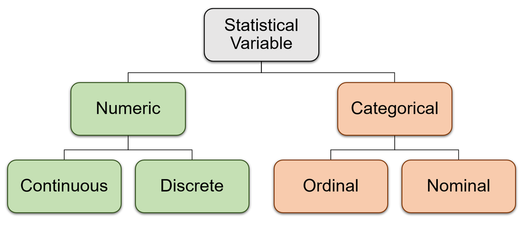

> Para identificar el tipo de variable que subyace a los datos hay que fijarse tanto en la “naturaleza” de la variable como en los valores que toma. Por ejemplo, si se tienen temperaturas, la variable es, per se, una variable cuantitativa/numérica continua, pero habitualmente se recoge como variable discreta (temperaturas máximas de una serie de días: 12ºC, 14ºC,…). Así, según los datos de temperatura de los que se disponga podrá considerarse como continua, discreta o incluso categórica: temperaturas fijadas para un horno en unos experimentos (150ºC, 210ºC, 240ºC). Otro ejemplo ilustrativo es la variable número de DNI, o número de teléfono. Aunque son números no indican una cantidad (no son cuantitativas), por lo que deben tratarse como variables categóricas. Todo esto, a los efectos de usar los resúmenes gráficos y numéricos más apropiados.

R ofrece multitud de *funciones* (vistas en la introducción) para trabajar con cualquier tipo de variable estadística a partir de datos primarios, que podrán ser introducidos manualmente o importados desde archivos. Separamos la explicación en variables cuantitativas y categóricas.

## 1.1 Variables **Cuantitativas/Numéricas**

Los datos de los que dispondremos **siempre** serán un conjunto de **valores discretos** (digamos que no podemos tener datos con infinitos decimales). Pero no todas las variables que consideramos son variables discretas. Como se ha dicho en el punto anterior, hay que mirar la “naturaleza” de la variables y los valores disponibles de ella para distinguir entre variables continuas y discretas. Para cada tipo, unos gráficos o una medidas de resumen serán más apropiados que otros. Concretamente, para las variables continuas el gráfico más apropiado es el **[histograma](https://campusvirtual.uclm.es/pluginfile.php/3179088/mod_resource/content/2/R-1_Descriptiva.html#histo)**, para las variables discretas o las categóricas el **[diagrama de barras](https://campusvirtual.uclm.es/pluginfile.php/3179088/mod_resource/content/2/R-1_Descriptiva.html#barplotD)** o el de **[sectores](https://campusvirtual.uclm.es/pluginfile.php/3179088/mod_resource/content/2/R-1_Descriptiva.html#pie)** . Éste último es útil cuando hay pocos valores/categorías distintos. Y el gráfico utilizado generalmente para detectar valores atípicos (outliers) es el **[diagrama de caja](https://campusvirtual.uclm.es/pluginfile.php/3179088/mod_resource/content/2/R-1_Descriptiva.html#boxplot)** o boxplot.

> Pero **no hay una regla de oro**. En ocasiones tendremos *variables discretas* que es más apropiado manejarlas como continuas, debido a su elevado número de valores distintos, y utilizaremos gráficos “reservados” para variables continuas.  
> O al revés, que a pesar de tener una *variable continua* sea conveniente un diagrama de barras, por el escaso número de valores distintos (como el ejemplo de las temperaturas de los hornos mencionado arriba, que al disponer sólo de 3 temperaturas distintas un histograma no es lo apropiado).

Del mismo modo, de entre las medidas de resumen que veremos: de [centralización](https://campusvirtual.uclm.es/pluginfile.php/3179088/mod_resource/content/2/R-1_Descriptiva.html#CentralCuantita), de [dispersión](https://campusvirtual.uclm.es/pluginfile.php/3179088/mod_resource/content/2/R-1_Descriptiva.html#DispCuantita), de [posición](https://campusvirtual.uclm.es/pluginfile.php/3179088/mod_resource/content/2/R-1_Descriptiva.html#PosCuantita) y de [forma](https://campusvirtual.uclm.es/pluginfile.php/3179088/mod_resource/content/2/R-1_Descriptiva.html#FormCuantita), algunas no tendrán mucho sentido para variables continuas, otras no lo tendrán para variables discretas. Por ejemplo, para una variable continua que tenga un gran número de valores distintos no tiene mucho sentido calcular la moda como el valor que más se repite (quizá ningún valor se repita). Veremos en un ejemplo que una variable cuantitativa tendrá varios valores con la misma máxima frecuencia y entonces ¿cuál es la moda?. Y para una variable discreta puede que no tenga mucho sentido calcular la curtosis dado que es un coeficiente que sirve para comparar con una distribución continua con forma de campana de Gauss.

**Ejemplos:**

1. El fichero `waitingtimes.txt` (disponible en moodle) contiene ciertos tiempos de espera.

> *Recordatorio:* Para poder cargar este fichero bien debe estar en el directorio de trabajo, bien debe especificarse su ubicación/ruta o… (véase el apartado “Importar/exportar datos” de la introducción a R).

> ```r
> ( wtime <- scan("waitingtimes.txt") ) #Recordad: sentencia entre paréntesis -> muestra resultado
> ```

> ```
> ##   [1] 79 54 74 62 85 55 88 85 51 85 54 84 78 47 83 52 62 84 52 79 51 47 78 69 74
> ##  [26] 83 55 76 78 79 73 77 66 80 74 52 48 80 59 90 80 58 84 58 73 83 64 53 82 59
> ##  [51] 75 90 54 80 54 83 71 64 77 81 59 84 48 82 60 92 78 78 65 73 82 56 79 71 62
> ##  [76] 76 60 78 76 83 75 82 70 65 73 88 76 80 48 86 60 90 50 78 63 72 84 75 51 82
> ## [101] 62 88 49 83 81 47 84 52 86 81 75 59 89 79 59 81 50 85 59 87 53 69 77 56 88
> ## [126] 81 45 82 55 90 45 83 56 89 46 82 51 86 53 79 81 60 82 77 76 59 80 49 96 53
> ## [151] 77 77 65 81 71 70 81 93 53 89 45 86 58 78 66 76 63 88 52 93 49 57 77 68 81
> ## [176] 81 73 50 85 74 55 77 83 83 51 78 84 46 83 55 81 57 76 84 77 81 87 77 51 78
> ## [201] 60 82 91 53 78 46 77 84 49 83 71 80 49 75 64 76 53 94 55 76 50 82 54 75 78
> ## [226] 79 78 78 70 79 70 54 86 50 90 54 54 77 79 64 75 47 86 63 85 82 57 82 67 74
> ## [251] 54 83 73 73 88 80 71 83 56 79 78 84 58 83 43 60 75 81 46 90 46 74
> ```

- Con la *asignación* anterior (`<-`), en el *objeto* `wtime` hemos introducido los datos del fichero.  
  ¿Es `wtime` una variable continua? A la vista de los datos (números enteros) parece que es una variable discreta, pero… ¡es un tiempo! (seguro que toma valores en un intervalo, que probablemente se han discretizado/redondeado). Y además, parecen muchos valores distintos. A la vista de esto, la trataremos como variable continua. Usaremos el histograma y los resúmenes numéricos de variables continuas, y veremos si son coherentes con considerarla continua.
2. Otra variable que usaremos, y que en este caso se encuentran entre los conjuntos de datos de R, es `Nile` que contiene los datos anuales del flujo del río Nilo a su paso por la presa de Asuán (Egipto): `?Nile`. ¿Variable continua?

> ```r
> Nile
> ```

> ```
> ## Time Series:
> ## Start = 1871
> ## End = 1970
> ## Frequency = 1
> ##   [1] 1120 1160  963 1210 1160 1160  813 1230 1370 1140  995  935 1110  994 1020
> ##  [16]  960 1180  799  958 1140 1100 1210 1150 1250 1260 1220 1030 1100  774  840
> ##  [31]  874  694  940  833  701  916  692 1020 1050  969  831  726  456  824  702
> ##  [46] 1120 1100  832  764  821  768  845  864  862  698  845  744  796 1040  759
> ##  [61]  781  865  845  944  984  897  822 1010  771  676  649  846  812  742  801
> ##  [76] 1040  860  874  848  890  744  749  838 1050  918  986  797  923  975  815
> ##  [91] 1020  906  901 1170  912  746  919  718  714  740
> ```

- De nuevo, los datos son “discretos” (números enteros), pero al tratarse de un flujo (naturaleza continua) y dado que se ven numerosos valores distintos se tratará como variable continua. Por tanto, también utilizaremos los resúmenes gráficos y numéricos para variables continuas, y veremos si son coherentes con tratar a esta variable como continua.
3. También usaremos los datos/variable `discoveries` de R. Para obtener información sobre su contenido y significado de cara a identificar mejor que tipo de variable es consúltese su ayuda: `?discoveries`.

> ```r
> discoveries
> ```

> ```
> ## Time Series:
> ## Start = 1860
> ## End = 1959
> ## Frequency = 1
> ##   [1]  5  3  0  2  0  3  2  3  6  1  2  1  2  1  3  3  3  5  2  4  4  0  2  3  7
> ##  [26] 12  3 10  9  2  3  7  7  2  3  3  6  2  4  3  5  2  2  4  0  4  2  5  2  3
> ##  [51]  3  6  5  8  3  6  6  0  5  2  2  2  6  3  4  4  2  2  4  7  5  3  3  0  2
> ##  [76]  2  2  1  3  4  2  2  1  1  1  2  1  4  4  3  2  1  4  1  1  1  0  0  2  0
> ```

- ¿Otra variable continua? A la vista de los valores, también enteros, y los casos anteriores, puede pensarse que sí. Ahora bien, el rango de valores no es tan grande como en las variables anteriores y no hay muchos valores distintos, sólo 12 (del 0 al 12, pero no hay ningún 11). ¿Será una variable discreta? La clave está en saber que la variable se define como “número de …” por lo que es teóricamente discreta (al ser “número de” no podrá tomar cualquier valor en un intervalo). Utilizaremos gráficos y medidas de resumen de variables discretas, viendo si son coherentes con que la variable sea discreta.
4. Una variable con decimales, porque hasta ahora sólo hemos visto variables con números enteros (aunque las hemos clasificado como continuas o discretas).

> ```r
> mtcars$mpg
> ```

> ```
> ##  [1] 21.0 21.0 22.8 21.4 18.7 18.1 14.3 24.4 22.8 19.2 17.8 16.4 17.3 15.2 10.4
> ## [16] 10.4 14.7 32.4 30.4 33.9 21.5 15.5 15.2 13.3 19.2 27.3 26.0 30.4 15.8 19.7
> ## [31] 15.0 21.4
> ```

> **Nota:** Ésta variable no desmiente lo dicho arriba: “siempre vamos a manejar datos discretos”. Porque su sentido es que siempre se tomarán datos con una determinada precisión. Esto es, no siempre serán números enteros, pero no se pueden tener datos con infinitos decimales.
- ¿Por tener decimales es la variable continua?  
  No siempre, hay que mirar más allá: ¿Definición/Naturaleza de la variable? ¿Cuántos valores se tienen? ¿cuántos valores distintos?… (Recordad el ejemplo de las temperaturas de hornos.)  
  Sobre `mtcars$mpg` a la vista de sus más de 30 valores y su variedad la clasificamos como continua y lo “confirmaremos” viendo la coherencia de sus gráficos y medidas resumen para variables continuas.

> El conjunto de datos o data frame `mtcars` (`?mtcars`) se usará varias veces a lo largo de este material.  
> Aunque ya se mencionó en la introducción y lo veremos en detalle más adelante, cabe aquí recordar que se trata de conjuntos de observaciones/individuos (dispuestas en filas) de las que se han recogido varias variables (dispuestas en columnas).

> ```r
> head(mtcars) #Muestra las primeras observaciones (filas) del conjunto de datos
> ```

> ```
> ##                    mpg cyl disp  hp drat    wt  qsec vs am gear carb
> ## Mazda RX4         21.0   6  160 110 3.90 2.620 16.46  0  1    4    4
> ## Mazda RX4 Wag     21.0   6  160 110 3.90 2.875 17.02  0  1    4    4
> ## Datsun 710        22.8   4  108  93 3.85 2.320 18.61  1  1    4    1
> ## Hornet 4 Drive    21.4   6  258 110 3.08 3.215 19.44  1  0    3    1
> ## Hornet Sportabout 18.7   8  360 175 3.15 3.440 17.02  0  0    3    2
> ## Valiant           18.1   6  225 105 2.76 3.460 20.22  1  0    3    1
> ```

> Y como se ha visto, la manera para “obtener” los valores de una variable de dicho conjunto es: `mtcars$...` donde los puntos suspensivos se sustituyen por la variable que se quiera obtener, por ejemplo, `mtcars$cyl`, `mtcars$disp`…

## 1.2 Gráficos

### 1.2.1 Histograma `hist()`

Es el gráfico más apropiado para una variable continua. Requiere de una agrupación de las observaciones por intervalos, excluyentes y exhaustivos, por lo que es recomendable cuando se tiene un número suficiente de datos (y suficientes valores distintos).

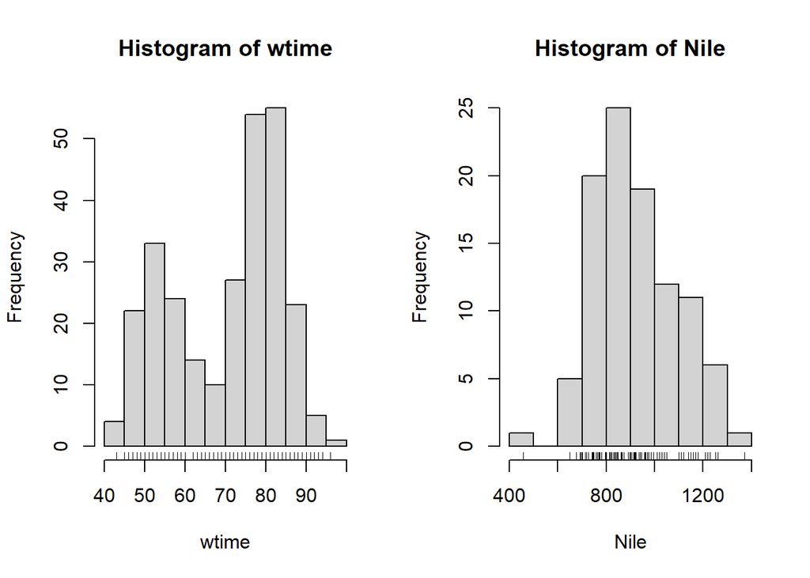

```r
par(mfrow = c(1, 2)) #Para hacer un mosaico de gráficos 1 fila x 2 columnas
#Para volver a 1 gráfico: par(mfrow = c(1, 1))
hist(wtime)
rug(wtime) #Representación de los datos en "formato alfombra" ("barritas" debajo del histograma)
# rug() ayuda a ver los distintos valores que toma la variable
hist(Nile); rug(Nile)
```

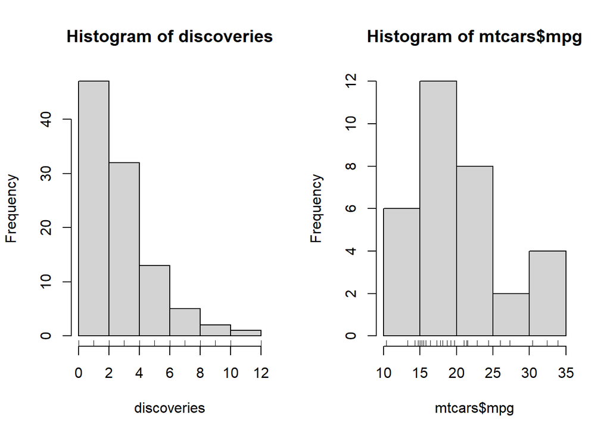

```r
hist(discoveries); rug(discoveries)
hist(mtcars$mpg); rug(mtcars$mpg)
```

Como se ve, los histogramas parecen apropiados para las cuatro variables, aunque sólo 3 de ellas (`wtime, Nile, mtcars$mpg`) hemos dicho que se podían considerar continuas.

Para la variable discreta `discoveries` se observa que son pocos valores distintos y enteros, por lo que es muy recomendable dibujar su [diagrama de barras](https://campusvirtual.uclm.es/pluginfile.php/3179088/mod_resource/content/2/R-1_Descriptiva.html#barplotD) (el apropiado para variables discretas) y compararlos.

Un efecto parecido al de `discoveries` se observa para `wtime` (gracias a la función `rug()`). Se ven claramente que sus datos son enteros y no tienen la misma apariencia que los datos “continuos” de `Nile` y `mtcars$mpg`. Por tanto, también conviene representar estos datos con un diagrama de barras y compararlos. De hecho, más adelante representaremos todas ellas como diagramas de barras para comentar las diferencias entre ambos gráficos.

**La clave es el área**

El histograma ha de leerse por **áreas**, dado que intenta mostrar la **densidad** de la distribución de probabilidad que hay “detrás” de los datos. Dicha densidad se obtiene utilizando **frecuencias relativas**, en lugar de las frecuencias absolutas. Para ello añadiremos el *argumento* `prob = TRUE`:

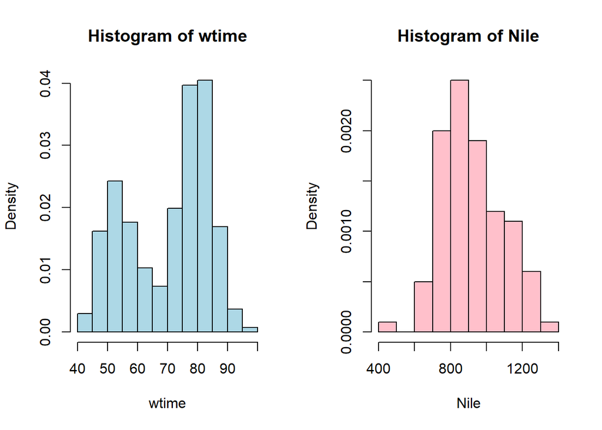

```r
par(mfrow = c (1, 2))
hist(wtime, prob  =  TRUE, col = "lightblue") #se ha aprovechado para cambiar el color por defecto
hist(Nile, prob = T, col = "pink") #Recordatorio: T es la abreviación de TRUE
```

> Lo único que ha cambiado, al usar *frecuencias relativas*, respecto a los histogramas anteriores es la escala del eje $Y$, que también cambia de poner frecuencia a poner densidad. Esto es, el histograma tendrá la misma “forma” aunque se utilicen frecuencias absolutas, relativas o porcentuales.  
> La clave, como se ha dicho, son las **áreas** y para ello conviene representar densidades. Estás se obtiene como cociente entre la frecuencia (de cualquier tipo) de cada clase y la *amplitud* de esa clase.

**Componentes de `hist`**

La función `hist` aplicada a un conjunto de datos genera, además del gráfico, un *objeto* de clase *lista* (visto en la introducción).

```r
histog_Nilo <- hist(Nile) #guardamos el "objeto" generado con la función hist
```

En dicho *objeto* se incluyen varios *componentes*, descritos en el apartado “Values” en la ayuda de la función `hist()`, que se pueden obtener utilizando la función `names()`:

```r
names(histog_Nilo)
```

```
## [1] "breaks"   "counts"   "density"  "mids"     "xname"    "equidist"
```

Ahora se pueden explorar cada uno de esos *componentes* (utilizando para ello el $):

```r
histog_Nilo$breaks #Puntos de corte, extremos de los intervalos
```

```
##  [1]  400  500  600  700  800  900 1000 1100 1200 1300 1400
```

```r
histog_Nilo$counts #Número de datos incluidos en cada clase
```

```
##  [1]  1  0  5 20 25 19 12 11  6  1
```

Puedes explorar por tu cuenta el resto para averiguar/intuir que proporcionan y acudir a la ayuda de la función para más detalles.

**Argumentos interesantes para `hist`**

Al representar un histograma con `hist()`, por defecto las clases son cerradas en su extremo superior. Si queremos que lo sean en su extremo inferior hemos de añadir el *argumento* `right = FALSE`.

```
hist(Nile, right = FALSE)$counts
```

También podemos *sugerir* el número de clases en las que se deben agrupar los datos, añadiendo el *argumento* `breaks = ...`. Como se ha visto `breaks` también es un *componente*.

```
hist(wtime, breaks = 4)$breaks #Se ve que es una sugerencia y no una imposición
length(hist(wtime, breaks = 30)$breaks) #Lo mismo, no hace 30 "barras"
```

> De nuevo, para averiguar todos los *argumentos* que se pueden proporcionar a la función `hist()` acúdase a la ayuda de la función: `?hist`.

### 1.2.2 Boxplot `boxplot()`

Es el gráfico que mejor resume la variabilidad contenida en una variable (continua o discreta). Se construye calculando los cuartiles (medidas de posición), $Q_1$, $Q_2=Me$ y $Q_3$, y el rango intercuartílico, `IQR`, que veremos en detalle más adelante ([aquí](https://campusvirtual.uclm.es/pluginfile.php/3179088/mod_resource/content/2/R-1_Descriptiva.html#PosCuantita)). Es el más apropiado cuando se tienen pocos datos. Se usa para detectar **valores atípicos/outliers**.

```
boxplot(Nile)
```

Por defecto, se representa verticalmente. Para que se represente horizontalmente se ha de añadir el *argumento* `horizontal = T`

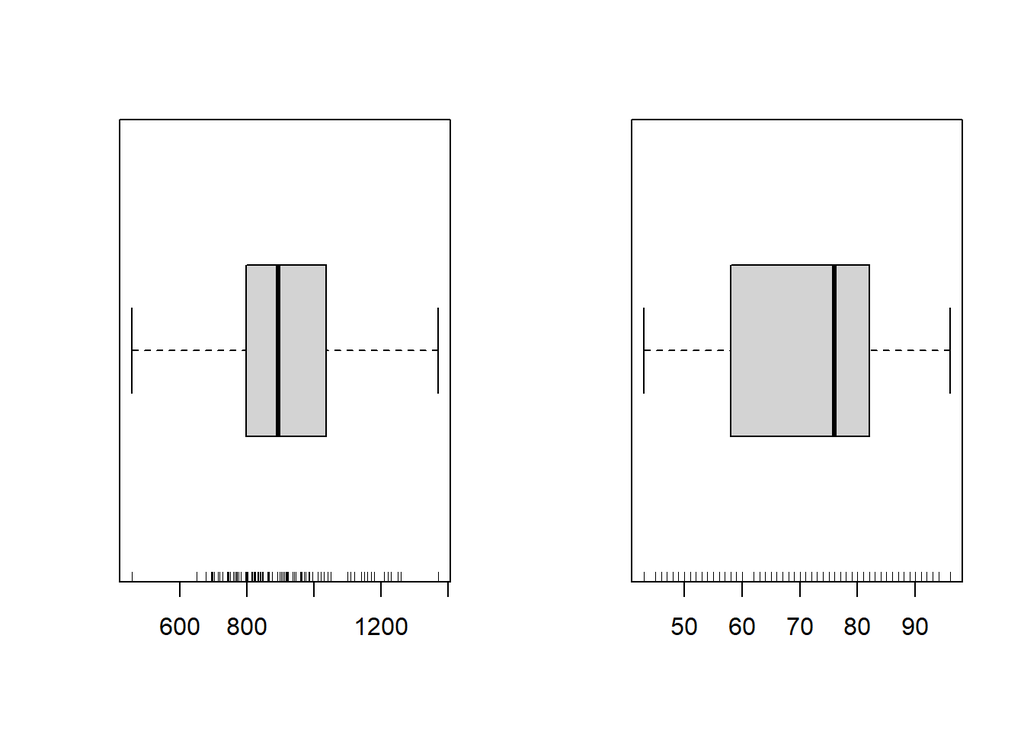

```r
par(mfrow = c (1,2))
boxplot(Nile, horizontal = T); rug(Nile)
boxplot(wtime, horizontal = TRUE); rug(wtime)
```

Uno de los *componentes* (`names(boxplot(...))`) del objeto generado con `boxplot()` nos proporciona los **out**liers.

```
boxplot(discoveries, horizontal = T)$out
```

En el gráfico se ven 4 puntos atípicos… ¿Y en el listado obtenido con `$out`?

> Puede que en el gráfico sólo se vea un punto, pero sean dos o más datos con el mismo valor:  
> `boxplot(c(discoveries, 12))$out`

El componente `$stats` proporciona los **cinco valores** siguientes basados en los cuartiles (que veremos en detalle más adelante, [aquí](https://campusvirtual.uclm.es/pluginfile.php/3179088/mod_resource/content/2/R-1_Descriptiva.html#PosCuantita)):

- Menor valor de los datos (ordenados) que sea igual o mayor que el límite inferior $LI = Q_1 - 1.5 \cdot IQR$. Hasta dicho menor valor es hasta donde se pinta el “bigote”.
- Primer cuartil, $Q_1$.
- Segundo cuartil o Mediana, $Q_2 = Me$.
- Tercer cuartil, $Q_3$.
- Mayor valor de los datos (ordenados) que sea menor o igual que el límite superior $LS = Q_3 + 1.5 \cdot IQR$. Hasta dicho mayor valor es hasta donde se pinta el “bigote”.

```r
boxplot(discoveries, plot = F)$stats
```

```
##      [,1]
## [1,]    0
## [2,]    2
## [3,]    3
## [4,]    4
## [5,]    7
```

> ¡Ojo! En algunos casos existen varias funciones con el mismo nombre para lo mismo (veremos más adelante el caso de `skewness`, función definida en varios *paquetes* para calcular la asimetría de los datos. El estar definidas en distintos paquetes es lo que permite que la función se llame igual. También veremos el caso de la función `kurtosis`).  
> En otros casos algunas funciones con nombres distintos pueden pensarse que sirven para la mismo, pueden ser equívocas, como `fivenum()` y `boxplot()$stats`. Ambas funciones proporcionan cinco valores y podría pensarse que son los citados arriba. Es más, el “inventor” del boxplot, John Tukey, fue el que acuñó el término cinco valores y `fivenum` obtiene los definidos por Tukey: el mínimo, los 3 cuartiles y el máximo de los datos.

> ```r
> fivenum(discoveries)
> ```

> ```
> ## [1]  0  2  3  4 12
> ```

> Por definición, los 5 valores de ambas funciones difieren en el primero y el último y coinciden en los otros 3 ($Q_1$, $Q_2$ y $Q_3$). Pero empíricamente ambas funciones pueden devolver los mismos 5 valores… En aquellos casos en que ¡no hay outliers/atípicos!

### 1.2.3 Diagrama de barras `barplot()`

Tal y como se ha comentado, para variables cuantitativas discretas el **diagrama de barras** suele ser el más apropiado. Pero hay excepciones, al igual que hemos visto para el [histograma](https://campusvirtual.uclm.es/pluginfile.php/3179088/mod_resource/content/2/R-1_Descriptiva.html#histo). Si se quiere mirar el diagrama de barras para variables categóricas pulse [aquí](https://campusvirtual.uclm.es/pluginfile.php/3179088/mod_resource/content/2/R-1_Descriptiva.html#barplot).

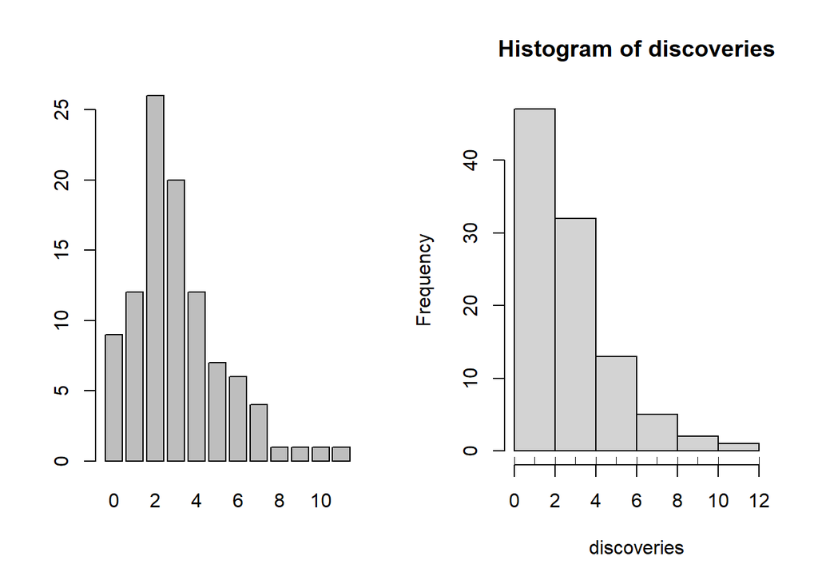

```r
par(mfrow = c (1,2))
barplot(table(discoveries)) #table() proporciona la tabla de frecuencias que veremos en detalle más adelante
hist(discoveries); rug(discoveries)
```

Con estos datos de `discoveries`, el histograma, al agrupar valores, presenta una imagen de decaimiento de las frecuencias distinta a la del diagrama de barras. Confirmando que, en este caso, es más apropiado el diagrama de barras como resumen gráfico de la variable discreta.

Veamos lo que ocurre con las otras variables consideradas anteriormente:`wtime`, `Nile` y `mtcars$mpg` todas catalogadas como continuas.

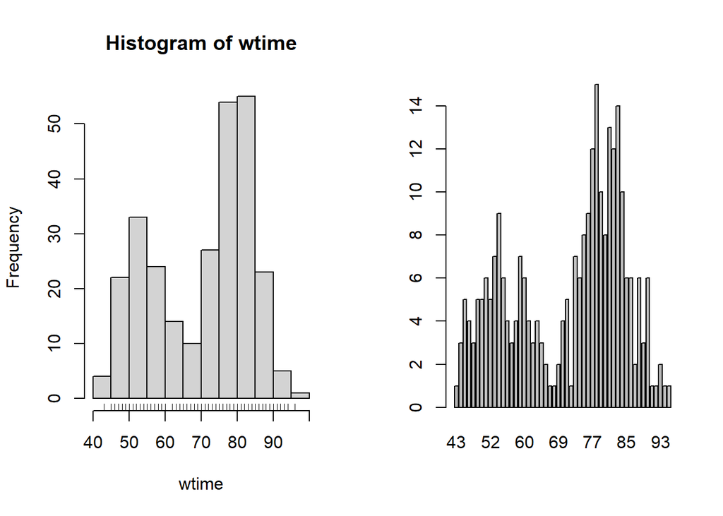

```r
par(mfrow = c (1, 2))
hist(wtime); rug(wtime)
barplot(table(wtime))
```

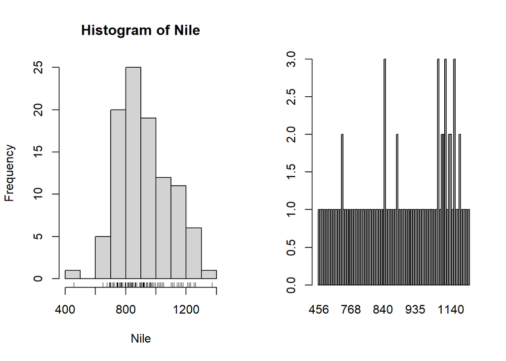

```r
hist(Nile); rug(Nile)
barplot(table(Nile))
```

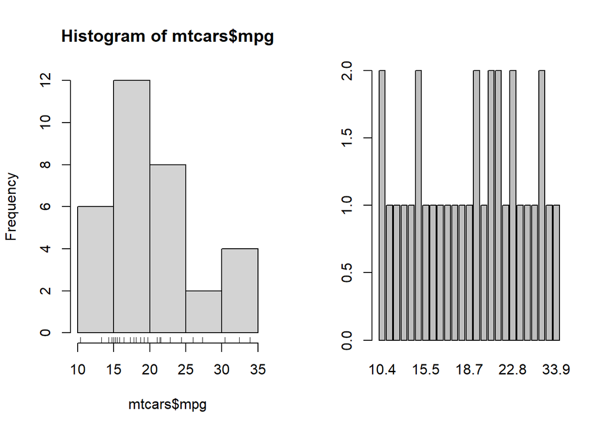

```r
hist(mtcars$mpg); rug(mtcars$mpg)
barplot(table(mtcars$mpg))
```

Los diagramas de barras de `Nile` y `mtcars$mpg` carecen de sentido para representar dichas variables. Sin embargo, el de `wtime` se asemeja al histograma, que es más apropiado que el diagrama de barras. El histograma refleja mejor que el diagrama de barras la densidad de la distribución que hay detrás de los datos.

> Para resumir gráficamente una variable conviene hacer distintos tipos de gráficos y elegir el más adecuado.

## 1.3 Cálculo de medidas de resumen

### 1.3.1 Resumen de R `summary()`

Podemos hacernos una primera idea/resumen de los datos con la función `summary()`, que nos proporciona su mínimo, máximo, media, mediana y resto de cuartiles.

```r
summary(wtime)
```

```
##    Min. 1st Qu.  Median    Mean 3rd Qu.    Max.
##    43.0    58.0    76.0    70.9    82.0    96.0
```

```r
summary(Nile)
```

```
##    Min. 1st Qu.  Median    Mean 3rd Qu.    Max.
##   456.0   798.5   893.5   919.4  1032.5  1370.0
```

```r
summary(discoveries)
```

```
##    Min. 1st Qu.  Median    Mean 3rd Qu.    Max.
##     0.0     2.0     3.0     3.1     4.0    12.0
```

### 1.3.2 Medidas de centralización

Para la **media aritmética** y la **mediana** disponemos de las funciones `mean()` y `median()`.

```r
mean(wtime); median(wtime)
```

```
## [1] 70.89706
```

```
## [1] 76
```

```r
mean(Nile); median(Nile)
```

```
## [1] 919.35
```

```
## [1] 893.5
```

```r
mean(discoveries); median(discoveries)
```

```
## [1] 3.1
```

```
## [1] 3
```

**Interpretación de la media**

Se ha dicho… un resumen puede ser tendencioso, engañar, ser inexacto … De ahí lo apropiado de presentar resúmenes gráficos y numéricos a la hora de describir un conjunto de datos y preguntarse por su interpretación.

Al ejecutar anteriormente `mean(wtime)` y observar el valor obtenido, 70.8970588, comparado con el histograma…

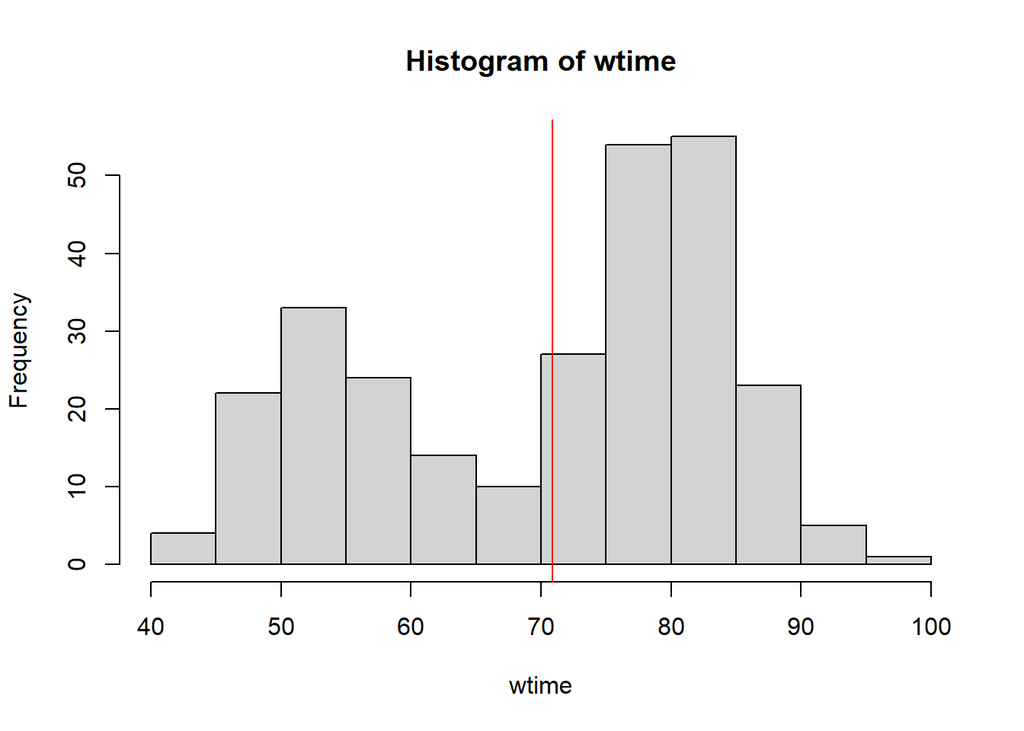

```r
hist(wtime)
abline(v = mean(wtime), col = "red") #Añade un línea vertical en el valor de la media
```

¿Es en este caso la media una medida razonable de tendencia central? Rotundamente, NO.  
Porque tenemos ante nosotros un claro ejemplo de distribución de frecuencias **bimodal**, donde los valores se distribuyen en torno a dos modas, una en torno al valor 55 y la otra en torno al valor 80. Y por tanto, la media (70.8970588) no representa un valor central al que tiendan los datos (no es apropiada en estos casos… Y la varianza/desviación típica que veremos un poco más adelante ¡dependen de ella!).

Sin embargo, para datos que presentan una distribución unimodal, como las variables `Nile` o `discoveries`, la media sí que es representativa de la tendencia central de los datos. Y más si la mediana es próxima a la media, más confianza tenemos en que cualquiera de los dos valores (si están cercanos) sirven bien para indicar/resumir el “centro” de los datos.

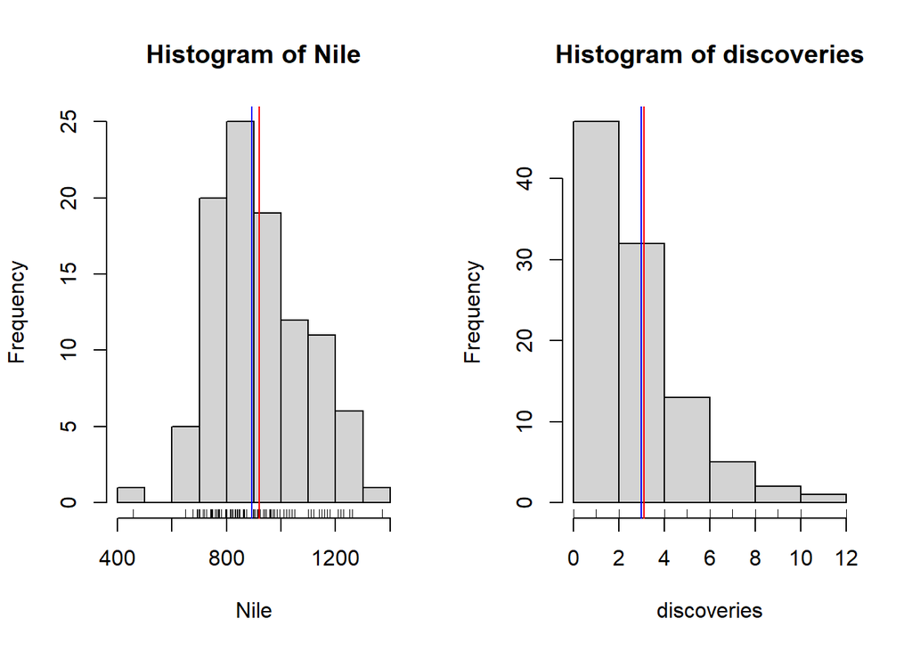

```r
par(mfrow = c(1, 2))
hist(Nile); rug(Nile);
abline(v = mean(Nile), col = "red"); abline(v = median(Nile), col = "blue")
hist(discoveries); rug(discoveries);
abline(v = mean(discoveries), col = "red"); abline(v = median(discoveries), col = "blue")
```

**Cálculos con valores perdidos**

Decíamos en la introducción que si entre los datos tenemos valores no disponibles (`NA`) los resultados de las funciones anteriores (y otras) serán `NA`. Para que R trabaje con el resto de datos, ignorando los valores `NA`, hemos de añadir en cada función (que lo admita) el *argumento* `na.rm = TRUE`.

```r
Nile2 <- c(Nile, NA); #Añadimos a los datos Nile un valor NA
tail(Nile2) #Muestra los últimos datos
```

```
## [1] 746 919 718 714 740  NA
```

```r
mean(Nile2);
```

```
## [1] NA
```

```r
mean(Nile2, na.rm = TRUE) #Obviamente la misma media que Nile
```

```
## [1] 919.35
```

**Moda**

No existe una función específica que nos proporcione la **moda**.

Una opción es usar la tabla de frecuencias y la función `which.max()`:

```r
which.max(table(Nile))
```

```
## 845
##  38
```

¿Cómo tiene que interpretarse la salida…? Ejecutemos

```r
table(Nile)
```

```
## Nile
##  456  649  676  692  694  698  701  702  714  718  726  740  742  744  746  749
##    1    1    1    1    1    1    1    1    1    1    1    1    1    2    1    1
##  759  764  768  771  774  781  796  797  799  801  812  813  815  821  822  824
##    1    1    1    1    1    1    1    1    1    1    1    1    1    1    1    1
##  831  832  833  838  840  845  846  848  860  862  864  865  874  890  897  901
##    1    1    1    1    1    3    1    1    1    1    1    1    2    1    1    1
##  906  912  916  918  919  923  935  940  944  958  960  963  969  975  984  986
##    1    1    1    1    1    1    1    1    1    1    1    1    1    1    1    1
##  994  995 1010 1020 1030 1040 1050 1100 1110 1120 1140 1150 1160 1170 1180 1210
##    1    1    1    3    1    2    2    3    1    2    2    1    3    1    1    2
## 1220 1230 1250 1260 1370
##    1    1    1    1    1
```

En esta tabla se ven los distintos valores que toma la variable, desde 456 a 1370, siendo el número que aparece debajo de cada uno su frecuencia (la mayoría de valores sólo aparecen una vez). Se puede apreciar que el 845 que había salido antes es el valor que más se repite (pero ¡sólo 3 veces!). El 38 de la segunda línea de la salida indica la posición que ocupa el 845 en la tabla de frecuencias.  
¿Tiene sentido con estos datos decir que la moda es 845?

Curiosamente, dicho valor 845 se encuentra, en este caso, en el intervalo modal (el de máxima frecuencia):

```r
hist(Nile)
```

Sin embargo, en la tabla de frecuencias también se aprecia que otros 3 números también se repiten 3 veces (esto mismo se puede apreciar en el diagrama de barras de `Nile` que se ha hecho arriba, y que se dijo que no era muy apropiado. En él se ven 4 barras que tienen igual máxima frecuencia, esto es, frecuencia 3). Con R podemos obtenerlos así:

```r
table(Nile)[table(Nile) == 3]
```

```
## Nile
##  845 1020 1100 1160
##    3    3    3    3
```

¿Estamos ante una distribución con varias modas? A la vista del histograma no. Pero al tener tantos valores distintos, con frecuencias bajas (viendo la tabla, las frecuencias son mayoritatiamente 1, se ven algunos 2 y el 3 aparece, como se ha visto 4 veces), se pueden dar situaciones así como se dijo al principio de este apartado 2.A (véase [aquí](https://campusvirtual.uclm.es/pluginfile.php/3179088/mod_resource/content/2/R-1_Descriptiva.html#ModaNOapro)). De hecho, la función arbitrariamente ha dado por moda el valor 845, que es el más pequeño de los valores de máxima frecuencia, así lo tiene definido internamente la función. Pero podría haber dado cualquier de los otros 3 valores…  
Este método, basado en la tabla de frecuencias, no es el adecuado para una variable continua. Como se ha visto en las clases de teoría, es más apropiado calcular la moda gráficamente, que en este caso conduce a un valor en torno a 844:

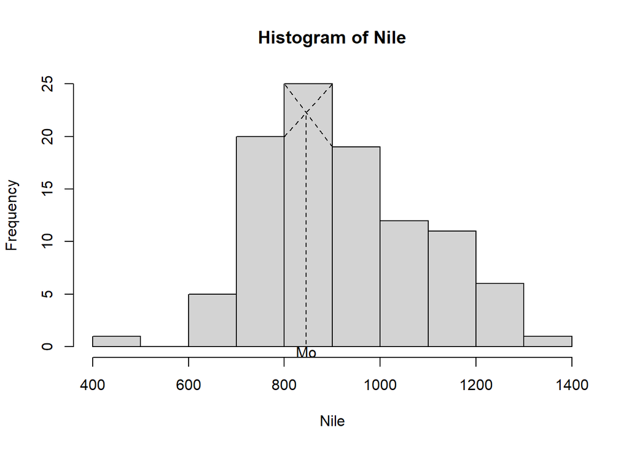

> **Material extra:**

> Aunque no vamos a ver en detalle como crear funciones con R, mostramos aquí un ejemplo. Creamos una función para obtener la **moda** de un conjunto de datos…

> ```r
> Mode <- function(x) {
>  ux <- unique(x)
>  ux[which.max(tabulate(match(x, ux)))]
> }
> ```

> La función se ha definido como `Mode()` porque ya hay una función `mode()` en R (recordad que R es sensible a mayúsculas/minúsculas).  
> La aplicamos al conjunto de datos `Nile`:

> ```r
> Mode(Nile)
> ```

> ```
> ## [1] 1160
> ```

> En este caso, ha tomado como moda el último valor de los 4 que ha encontrado de máxima frecuencia, que no resultar ser un valor muy razonable para la moda a la vista del histograma. Se concluye así que, para variables continuas, obtener la moda como el valor de máxima frecuencia de la tabla de frecuencias absolutas no es la mejor solución.

### 1.3.3 Medidas de dispersión

R nos ofrece las funciones `var()`, `sd()`, `range()`, `IQR()` para obtener, respectivamente, la **cuasivarianza**, la **cuasidesviación típica**, el **rango** y el **rango intercuartílico**.

```r
var(Nile); sd(Nile)
```

```
## [1] 28637.95
```

```
## [1] 169.2275
```

```r
var(discoveries); sd(discoveries)
```

```
## [1] 5.080808
```

```
## [1] 2.254065
```

```r
range(Nile)
```

```
## [1]  456 1370
```

```r
range(discoveries)
```

```
## [1]  0 12
```

```r
IQR(Nile)
```

```
## [1] 234
```

```r
IQR(discoveries)
```

```
## [1] 2
```

> Es “curioso” que el **rango** y el rango intercuartílico se “presenten” de forma distinta.  
> El IQR devuelve la diferencia entre el $Q_3$ y el $Q_1$ (que veremos a continuación).  
> El rango, como ya se ha dicho, devuelve los valores del mínimo y el máximo. Una forma de obtener su diferencia es:

> ```r
> diff(range(Nile))
> ```

> ```
> ## [1] 914
> ```

Si en lugar de la cuasivarianza (`var`) y la cuasidesviación típica (`sd`), se quiere obtener la **varianza** y **desviación típica** tal y como se han definido en clase:

$$S^2=\dfrac{\sum_i f_i(x_i - \bar{x})^2}{n} \quad \mbox{y} \quad S=\sqrt{S^2}$$
no queda más remedio que “acudir” a calcularlas usando tales fórmulas u obtenerlas a partir de las anteriores:

```r
NN <- length(Nile); media <- mean(Nile)
( varianza <- sum((Nile - media)^2)/NN ); var(Nile)*(NN - 1)/NN
```

```
## [1] 28351.57
```

```
## [1] 28351.57
```

```r
( desvtip <- sqrt(varianza) ); sd(Nile)*sqrt((NN - 1)/NN)
```

```
## [1] 168.3792
```

```
## [1] 168.3792
```

Para el **coeficiente de variación** no tenemos una función concreta, por lo que hemos de calcularlo aplicando su fórmula:

```r
sd(Nile)/abs(mean(Nile)) #Consideramos sd en lugar de "desvtip"
```

```
## [1] 0.184073
```

```r
sd(discoveries)/abs(mean(discoveries))
```

```
## [1] 0.7271177
```

Interpretación: Los valores de `Nile` tienen mayor dispersión absoluta que los de `discoveries` pero menor dispersión relativa. También se suele decir por ello que los valores de `Nile` son más homogéneos.

### 1.3.4 Medidas de posición

La función `quantile()` proporciona **cuantiles**, **percentiles**, **cuartiles**, **deciles**, etc. dependiendo del *argumento* que se le proporcione:

```r
quantile(Nile); quantile(Nile, c(.21, .15, .9))
```

```
##     0%    25%    50%    75%   100%
##  456.0  798.5  893.5 1032.5 1370.0
```

```
##     21%     15%     90%
##  773.37  745.70 1160.00
```

Como se ve, si no se le proporcionan más *argumentos* que la variable o vector de datos, devuelve el valor mínimo (percentil 0), los tres cuartiles, $Q_1, Q_2=Me$ y $Q_3$ (percentiles 25, 50 y 75 respectivamente) y el valor máximo (percentil 100).

En el segundo caso se le ha pedido unas medidas de posición concretas, los percentiles 21, 15 y 90 (o decil 9).

> R tiene implementados 9 algoritmos diferentes para calcular las medidas de posición. Si se quiere utilizar uno en concreto conviene usar `?quantile` para ver sus definiciones y poder seleccionar el `type` que interese. Por defecto utiliza el `type = 7` y si se utiliza el `type = 6` se obtienen los mismos valores que con el método explicado en los apuntes de teoría para datos sin agrupar, esto es considerando $n+1$ para calcular la posición del percentil.

> ```r
> datos.clase <- c(280, 283, 287, 288, 288, 289, 289, 290, 290, 290, 292, 293, 293, 293)
> quantile(datos.clase); quantile(datos.clase, type = 7); quantile(datos.clase, type = 6)
> ```

> ```
> ##    0%   25%   50%   75%  100%
> ## 280.0 288.0 289.5 291.5 293.0
> ```

> ```
> ##    0%   25%   50%   75%  100%
> ## 280.0 288.0 289.5 291.5 293.0
> ```

> ```
> ##     0%    25%    50%    75%   100%
> ## 280.00 287.75 289.50 292.25 293.00
> ```

Estamos en disposición de hacer los cálculos de los cinco valores del boxplot que se especificaban anteriormente ([aquí](https://campusvirtual.uclm.es/pluginfile.php/3179088/mod_resource/content/2/R-1_Descriptiva.html#fivenum)):

```r
boxplot(discoveries, plot = F)$stats
```

```
##      [,1]
## [1,]    0
## [2,]    2
## [3,]    3
## [4,]    4
## [5,]    7
```

Para ello obtenemos primero los cuartiles de la variable con la función vista en este apartado y comprobamos que `fivenum` “devuelve” el mismo resultado:

```r
quantile(discoveries); fivenum(discoveries)
```

```
##   0%  25%  50%  75% 100%
##    0    2    3    4   12
```

```
## [1]  0  2  3  4 12
```

Con los tres cuartiles calculamos los límites de los bigotes del diagrama de caja:

```r
( Limites <- c(quantile(discoveries, 0.25)[[1]] - 1.5 * IQR(discoveries),
               quantile(discoveries, 0.75)[[1]] + 1.5 * IQR(discoveries)) )
```

```
## [1] -1  7
```

El límite inferior obtenido es -1 y el valor más pequeño en los datos es 0: confirmamos que el bigote inferior llega hasta el 0 (no hasta el -1, pues no tenemos ningún valor entre el 0 y el -1).  
El límite superior obtenido es 7 y el valor más grande de entre los datos es 12. Así que todos los valores mayores que 7 serán outliers (y se representan con un círculo en el boxplot). Y el bigote superior llegará hasta el 7 (que es el máximo valor de los datos que es menor o igual al límite superior obtenido).

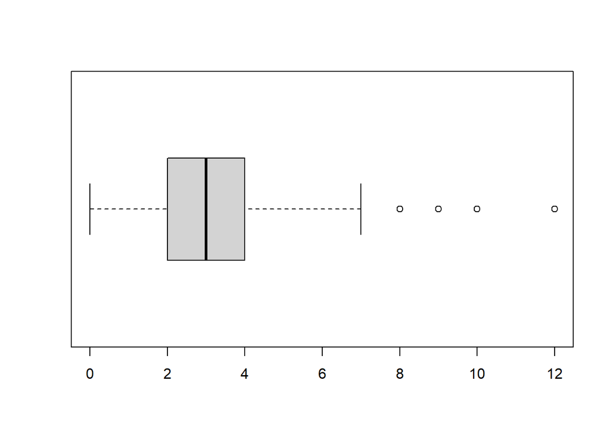

```r
boxplot(discoveries, horizontal = T)
```

> Podemos probar a añadir un valor a `discoveries` (dentro o fuera de los límites calculados) y ver cómo cambia el boxplot:

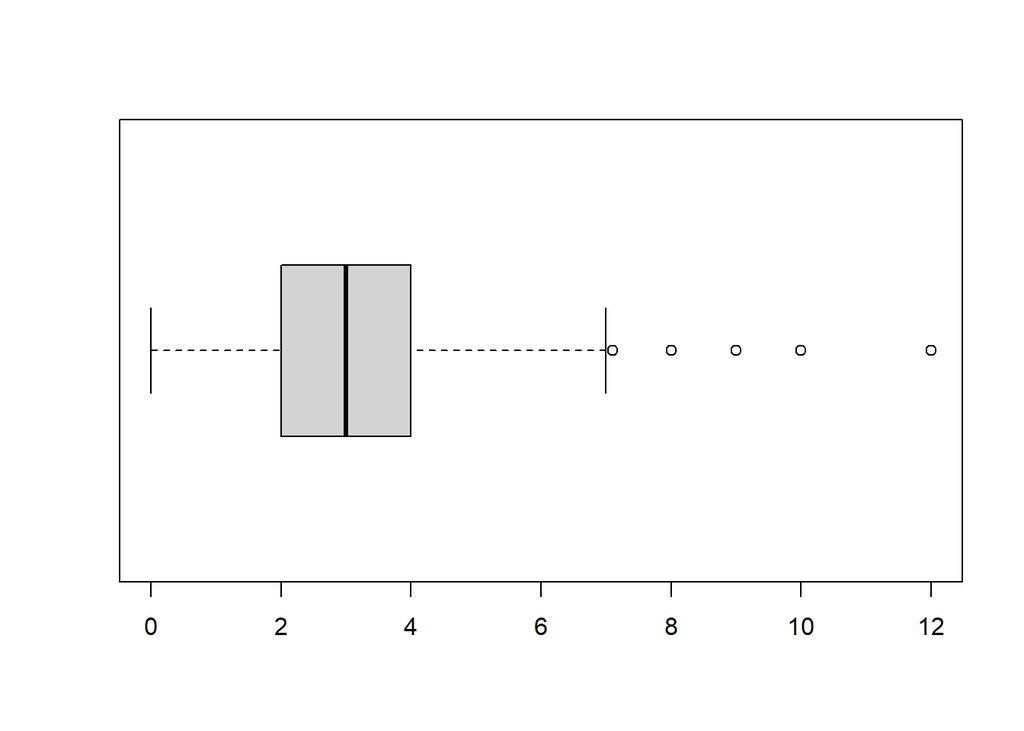

> ```
> ## [1] 12.0 10.0  9.0  8.0  7.1
> ```

> ```r
> boxplot(c(discoveries, 7.1), horizontal = T)$out #Se añade el valor 7.1
> ```

> En realidad los límites pueden cambiar al añadir un valor, pero, con un número suficiente de datos, puede darse el caso de que no varíen (como ocurre en este caso) o que la variación sea mínima.

### 1.3.5 Medidas de forma

En cuanto a las medidas de forma, R dispone de diversos *paquetes* con funciones para calcular la **asimetría** y la **curtosis**. De entre ellos nos centraremos en los paquetes `moments` y `e1071`, que contienen funciones con el mismo nombre para el cálculo de la asimetría, `skewness()`, y la curtosis, `kurtosis()`.

> Los paquetes adicionales hay que instalarlos y cargarlos.  
> Basta instalarlos 1 vez, pero hay que cargarlos en cada sesión en la que los vayamos a utilizar (véase el apartado “Instalación de paquetes” de la introducción).

> ```r
> library(moments)
> library(e1071)
> ```

Al estudiar cualquier medida, especialmente las medidas de forma, es fundamental la observación visual, por lo que debemos utilizar la representación gráfica junto con los resultados proporcionados por los coeficientes.

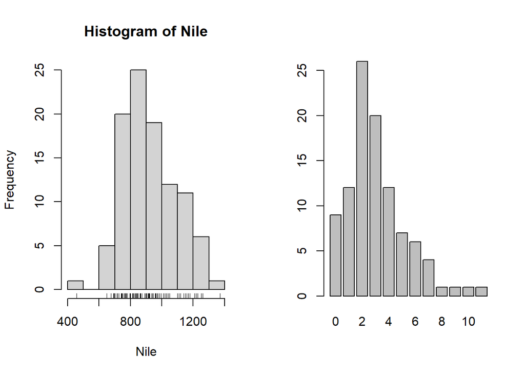

```r
par(mfrow = c (1, 2))
hist(Nile); rug(Nile)
barplot(table(discoveries))
```

```r
(sum((Nile - mean(Nile))^3) / length(Nile)) / (sd(Nile)^3); e1071::skewness(Nile)
```

```
## [1] 0.3175462
```

```
## [1] 0.3175462
```

```r
e1071::skewness(discoveries)
```

```
## [1] 1.2076
```

```r
e1071::kurtosis(Nile); e1071::kurtosis(discoveries)
```

```
## [1] -0.3585392
```

```
## [1] 1.989659
```

Se ha calculado el coeficiente de asimetría de `Nile` de dos maneras: con la fórmula teórica vista en clase (nótese que usamos `sd` por lo que realmente se está utilizando la cuasidesviación típica) y con la función `skewness` (tomada del paquete `e1071`, por ser el último cargado). Ambos coinciden en valor.

El coeficiente de asimetría de `Nile` es menor que el de `discoveries` como es obvio por los gráficos. Ambos coeficientes son positivos indicando que existe una cola a la derecha, muy clara para los datos `discoveries`.

> Por esta interpretación de la curtosis como comparación con la distribución normal, el coeficiente de curtosis de `discoveries` hay que interpretarlo con cautela, por tratarse de una variable discreta.  
> Tampoco sería interpretable cuando se tuviese una distribución bimodal como `wtime` o extremadamente asimétrica (con *forma* muy alejada de una distribución normal).

**Misma función (nombre) en distintos paquetes:**

Como se ha dicho las funciones `skewness()` y `kurtosis()` (con el mismo nombre) se encuentran en distintos paquetes, pero no están implementadas exactamente igual. En tales casos, es altamente recomendable utilizar la función con el nombre del paquete:

```
e1071::skewness(Nile)
e1071::skewness(Nile, type = 1) #¿Qué "type" usa por defecto?
moments::skewness(Nile)

e1071::kurtosis(Nile)
e1071::kurtosis(Nile, type = 1)
moments::kurtosis(Nile) - 3 #Es necesario el -3 para comparar con la "normal"
```

## 1.4 Variables **Categóricas/Cualitativas**

Las variables podrán ser nominales u ordinales. En primer lugar, como en el caso de las variables cuantitativas/numéricas, hay que introducir/importar los datos.

Como ya se ha dicho, unos gráficos o unas medidas de resumen serán más apropiados que otros. Concretamente, para las variables categóricas el gráfico más apropiado es el **diagrama de barras**. También se suele utilizar el **diagrama de sectores**, pero hay ciertos matices a tener en cuenta antes de utilizarlo (como veremos).

**Ejemplos**

1. Vamos a introducir los resultados de una encuesta en la que se podía responder *yes*, *no* o *ref* (refuses). Los introducimos tal cual, en formato texto. También introducimos los resultados de usuarios que señalaban que producto de entre tres distintos le satisfacía más, definido con los valores *1*, *2* o *3*, pero que podrían ser A, B o C.

   ```r
   survey <- c("y", "n", "n", "y", "ref", "y", "n", "y", "ref", "n")
   satisf <- c(1, 3, 2, 1, 1, 2, 1, 2, 3, 3, 1, 1, 2, 3, 2, 1, 2, 3, 3, 2)
   ```

   Ambas variables se pueden clasificar como nominales, no hay un orden entre sus categorías.  
   ¿O entre sí, no y ref hay un orden claro?  
   Sin embargo, parecería que entre 1, 2 y 3 si que hay un orden, pero tal y como está definida la variable podría ser A, B o C, que parece que también tiene un orden. Pensad en que se está eligiendo la asignatura favorita de entre Física, Cálculo y Estadística ¿hay un orden claro entre las asignaturas para asignarles el 1, el 2 y el 3?
2. Como variable ordinal para usar en los resúmenes posteriores utilizaremos `mtcars$cyl` que contiene el número de cilindros de varios modelos de coches.

   ```r
   mtcars$cyl
   ```

   ```
   ##  [1] 6 6 4 6 8 6 8 4 4 6 6 8 8 8 8 8 8 4 4 4 4 8 8 8 8 4 4 4 8 6 8 4
   ```

   Al ser número de cilindros se puede manejar la variable como discreta, pero se observa que se tienen sólo tres valores distintos lo que en la práctica hace que sea más lógico manejarla como categórica. Y con un orden: 4 cilindros, 6 cilindros y 8 cilindros (o el inverso, pero no tiene sentido otro orden).
3. Como variables ordinales sin atisbo de duda de confundirla con una variable discreta definimos las siguientes que recogen el “curso más alto en el que se está matriculado” de un grupo de alumnos:

   ```r
   curso <- c("Prim", "Segu", "Segu", "Prim", "Prim", "Segu", "Prim", "Cuar",
              "Terc", "Prim", "Terc", "Prim", "Prim", "Cuar", "Prim", "Prim")
   Ncurs <- c("1Pri", "2Seg", "2Seg", "1Pri", "1Pri", "2Seg", "1Pri", "4Cua",
              "3Ter", "1Pri", "3Ter", "1Pri", "1Pri", "4Cua", "1Pri", "1Pri")
   ```

   En el siguiente apartado se explica porqué se han definido 2 variables con diferentes cadenas de caracteres, para los mismos “valores”.

## 1.5 Tablas de frecuencias

La **tabla de frecuencias absolutas** la podemos obtener con la función `table()`:

```r
table(survey)
```

```
## survey
##   n ref   y
##   4   2   4
```

```r
table(satisf)
```

```
## satisf
## 1 2 3
## 7 7 6
```

```r
table(mtcars$cyl)
```

```
##
##  4  6  8
## 11  7 14
```

```r
table(curso); table(Ncurs)
```

```
## curso
## Cuar Prim Segu Terc
##    2    9    3    2
```

```
## Ncurs
## 1Pri 2Seg 3Ter 4Cua
##    9    3    2    2
```

> R ordena los distintos valores de una variable para la tabla de frecuencias
> - de menor a mayor los valores numéricos
> - alfabéticamente los valores de tipo carácter.

> De aquí que se hayan definido los valores de `Ncurs` empezando por números para tener la ordenación natural de las categorías, pues la ordenación alfabética de las categorías de `curso` no es la natural, pone primero la categoría Cuar.

Las **frecuencias relativas** las podemos calcular con:

```r
table(survey) / length(survey)
```

```
## survey
##   n ref   y
## 0.4 0.2 0.4
```

O haciendo uso de la función `prop.table()`:

```
prop.table(table(survey))
prop.table(table(satisf))
prop.table(table(mtcars$cyl))
prop.table(table(curso))
prop.table(table(Ncurs))
```

Para las **frecuencias absolutas acumuladas** (que habrá que ver si tienen sentido) disponemos de la función `cumsum()`.

```r
cumsum(table(survey))
```

```
##   n ref   y
##   4   6  10
```

No parece que tenga mucho sentido “acumular” estas frecuencias de `survey`. Porque no es una variable ordinal, que tenga sentido acumular categorías. Veamos con las variables ordinales.

```r
cumsum(table(mtcars$cyl))
```

```
##  4  6  8
## 11 18 32
```

```r
cumsum(table(curso)); cumsum(table(Ncurs))
```

```
## Cuar Prim Segu Terc
##    2   11   14   16
```

```
## 1Pri 2Seg 3Ter 4Cua
##    9   12   14   16
```

Para estas últimas variables si tiene sentido acumular las frecuencias. Pero, por lo dicho arriba, el orden de `curso` no es el apropiado, mientras que el de `Ncurs` sí. Apropiado en el sentido de que se pueden hacer interpretaciones como: Hay 12 alumnos matriculados hasta en segundo curso (entiendo así matriculados en primero y segundo). O, para la variable `cyl` del conjunto `mtcars`, un total de 18 coches tienen 6 cilindros o menos.

> Para variables agrupadas en clases (variables continuas), las frecuencias acumuladas dependerán de número de clases y su amplitud, por lo que se debe aplicar la función `cumsum()` al componente `hist()$counts`:

> ```r
> ( freqNile <- hist(Nile)$counts )
> ```

> ```
> ##  [1]  1  0  5 20 25 19 12 11  6  1
> ```

> ```r
> cumsum(freqNile)
> ```

> ```
> ##  [1]   1   1   6  26  51  70  82  93  99 100
> ```

## 1.6 Gráficos

### 1.6.1 Diagrama de barras `barplot()`

Ya se ha visto ([aquí](https://campusvirtual.uclm.es/pluginfile.php/3179088/mod_resource/content/2/R-1_Descriptiva.html#barplot)) la función `barplot()` para representar un diagrama de barras. Y que lo apropiado es hacer el diagrama con `table()`, la tabla de frecuencias de la variable. Porque si se aplica directamente a la variable las barras representarán la altura correspondiente a su valor (numérico, si es carácter dará un error).

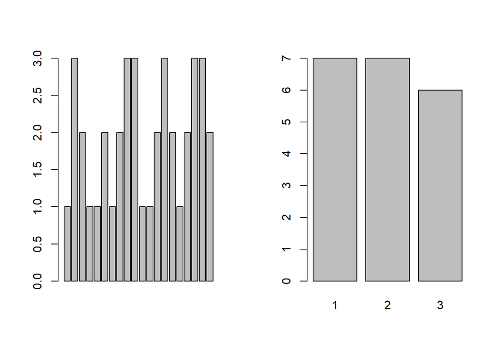

```r
par(mfrow = c(1, 2))
barplot(satisf)
barplot(table(satisf))
```

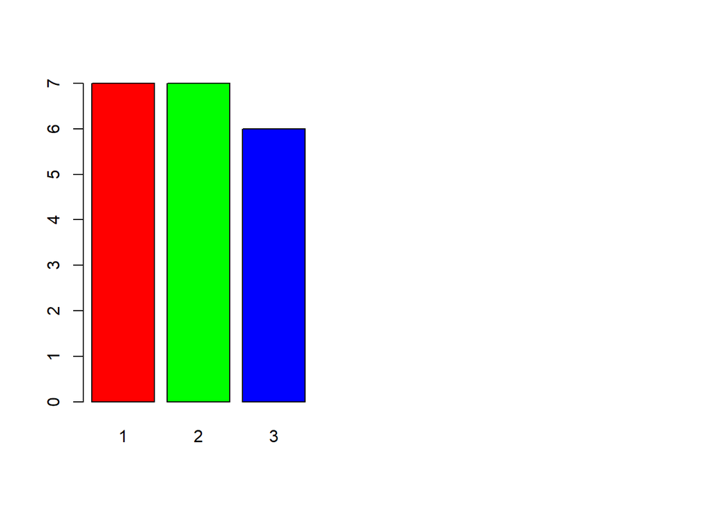

```r
barplot(table(satisf), col = rainbow(3)) #Aprovechando para cambiar el color
```

### 1.6.2 Diagrama de sectores `pie()`

El **diagrama de sectores** se obtiene con la función `pie()`, aplicada también a la tabla de frecuencias de la variable, `table()`. **Es útil cuando hay pocos valores/categorías, pero, se “lee” peor que uno de barras** (que siempre puede hacerse para los mismos datos).

> De la ayuda de la función, `?pie`:  
> “**Pie charts are a very bad way of displaying information**. **The eye is** good at judging linear measures and **bad at judging relative areas**. A bar chart or dot chart is a preferable way of displaying this type of data.  
> Cleveland (1985), page 264: “Data that can be shown by pie charts always can be shown by a dot chart. This means that judgements of position along a common scale can be made instead of the less accurate angle judgements.” This statement is based on the empirical investigations of Cleveland and McGill as well as investigations by perceptual psychologists."

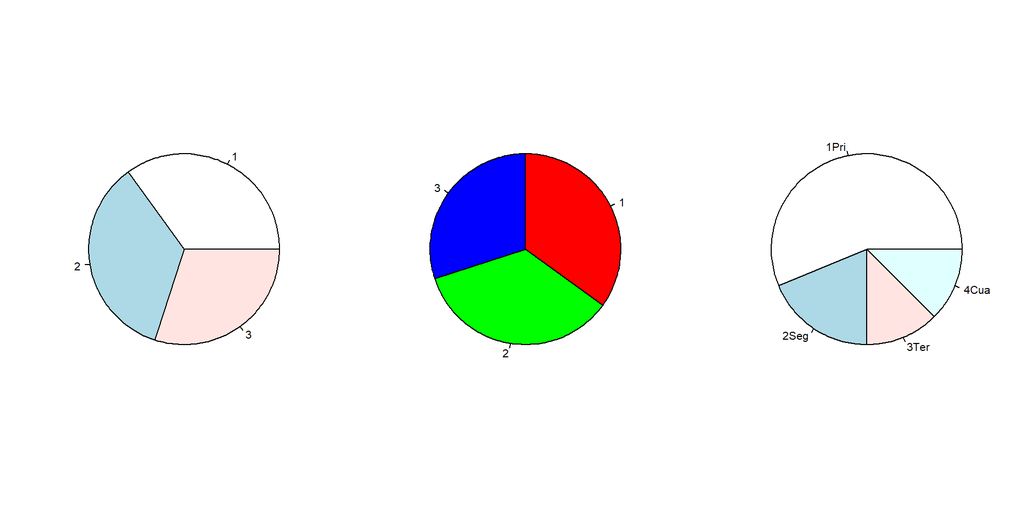

```r
par(mfrow = c(1, 3))
pie(table(satisf)) #Por defecto lleva color
pie(table(satisf), col = rainbow(3), clockwise = T) #Aprovechando para cambiar el color, y el "inicio"
pie(table(Ncurs)) #Comparación complicada si no se tiene la tabla de frecuencias
```

Lo dicho, en el caso de `satisf` el diagrama de sectores se lee peor que el de barras: parece que los tres sectores son igual de grandes, mientras que en su diagrama de barras, mostrado arriba, se puede ver que las categorías 1 y 2 tienen la misma frecuencia, pero la 3 es una unidad menor.

## 1.7 Cálculo de medidas de resumen

La medida que siempre tiene sentido obtener de una variable categórica es la **moda** (vista anteriormente [aquí](https://campusvirtual.uclm.es/pluginfile.php/3179088/mod_resource/content/2/R-1_Descriptiva.html#Mode)).

```r
table(survey)
```

```
## survey
##   n ref   y
##   4   2   4
```

```r
which.max(table(survey))  #Recordatorio: si hay varias "devuelve" la primera moda que encuentra
```

```
## n
## 1
```

```r
table(survey)[which.max(table(survey))] #Proporciona la frecuencia de la moda
```

```
## n
## 4
```

```r
Mode(survey) #Con la función que se ha definido antes, que "devuelve" la última moda
```

```
## [1] "y"
```

Si añadimos un “y” a `survey`, deshacemos el empate de frecuencias y la moda es precisamente “y” (que ocupa la posición 3 en la tabla de frecuencias, dato que aparece en la segunda fila de la salida).

```r
survey2 <- c(survey, "y")
which.max(table(survey2)); Mode(survey2)
```

```
## y
## 3
```

```
## [1] "y"
```

```r
table(curso); which.max(table(curso)); table(curso)[which.max(table(curso))]
```

```
## curso
## Cuar Prim Segu Terc
##    2    9    3    2
```

```
## Prim
##    2
```

```
## Prim
##    9
```

> A veces, como mera referencia sin un significado estricto, se obtienen algunas otras medidas para variables categóricas *ordinales*:

> ```r
> table(satisf); mean(satisf); median(satisf); which.max(table(satisf))
> ```

> ```
> ## satisf
> ## 1 2 3
> ## 7 7 6
> ```

> ```
> ## [1] 1.95
> ```

> ```
> ## [1] 2
> ```

> ```
> ## 1
> ## 1
> ```

> Pero hay que interpretar estos resultados con mucha precaución. De hecho, `satisf` no es una variable ordinal, por lo que ¿qué significado/interpretación se le puede dar a dichos valores?

# 2 Estadística descriptiva bivariante con R

La estadística multivariante se utiliza para estudiar la relación existente entre 2 o más variables. Estas variables pueden ser tanto categóricas como cuantitativas/numéricas. En este material vamos a ver las siguientes combinaciones bivariantes:

1. Categórica-Categórica. Por ejemplo, género (hombre, mujer) y estudios en curso (ingeniería, medicina)
2. Cuantitativa-Categórica. Por ejemplo, peso (en kg) y género (hombre, mujer)
3. Cuantitativa-Cuantitativa. Por ejemplo, peso (en kg) y altura (cm)

Nos centraremos en las combinaciones 1) y 3). La combinación 2) la veremos en inferencia, cuando estudiemos el *Análisis de la Varianza* (ANOVA).

## 2.1 Dos variables **categóricas**

Por ejemplo, podemos considerar un caso en el que se dispone de la información de un cliente que ha mostrado su impresión sobre un determinado producto antes de probarlo (`baseline`) y después (`testing`), indicando que le ha gustado (good/g/1) o que no (bad/b/0). Es importante tener en cuenta que aunque en este ejemplo se vayan a representar dos variables de tipo categórico, también se pueden utilizar valores numéricos para representar la información (de hecho, en la práctica es lo habitual, asignar números a las categorías). En R se haría de la siguiente forma:

```r
baseline <- c("b", "b", "g", "b", "b", "g", "b", "g", "g", "b")
testing <- c(1, 0, 1, 1, 0, 1, 0, 0, 1, 1)
```

Pudiéndose obtener la **tabla de frecuencias absolutas conjuntas** utilizando, de nuevo, la función `table()`.

```r
( tab <- table(baseline, testing) )
```

```
##         testing
## baseline 0 1
##        b 3 3
##        g 1 3
```

También se podría obtener la **tabla de frecuencias relativas conjuntas** o las **porcentuales** haciendo las operaciones oportunas, como vimos en el apartado anterior, o con la función `prop.table()` específica para ello :

```r
tab / length(testing); prop.table(tab) * 100
```

```
##         testing
## baseline   0   1
##        b 0.3 0.3
##        g 0.1 0.3
```

```
##         testing
## baseline  0  1
##        b 30 30
##        g 10 30
```

Además la función `addmargins()` nos permite añadir las **frecuencias marginales** de cada una de las dos variables a la tabla.

```r
addmargins(tab)
```

```
##         testing
## baseline  0  1 Sum
##      b    3  3   6
##      g    1  3   4
##      Sum  4  6  10
```

Pudiéndose obtener las frecuencias marginales tanto por filas como por columnas usando la función `margin.table()`.

```r
margin.table(tab, 1) #Por filas
```

```
## baseline
## b g
## 6 4
```

```r
margin.table(tab, 2) #Por columnas
```

```
## testing
## 0 1
## 4 6
```

Al igual que en estadística descriptiva unidimensional, R nos permite trabajar con varios tipos de gráficos para visualizar la información de la que se dispone. En el caso de 2 variables categóricas, se suelen utilizar **diagramas de barras** para representar la tabla de frecuencias conjunta con la función `barplot()`.

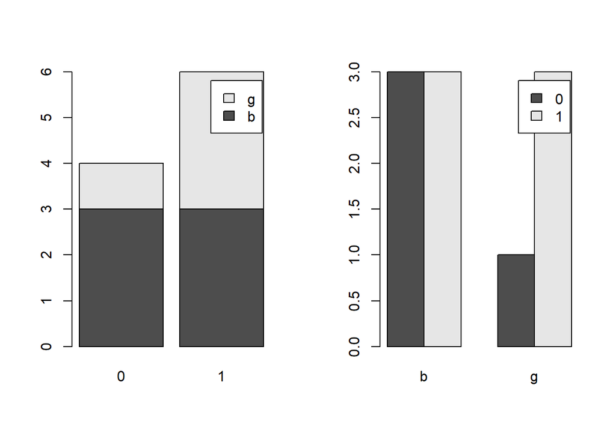

```r
par(mfrow = c(1, 2))
barplot(tab, legend.text = T)  #Cada barra es una columna
barplot(t(tab), legend.text = T, beside = T) #t() traspone la tabla ==> barras por filas
```

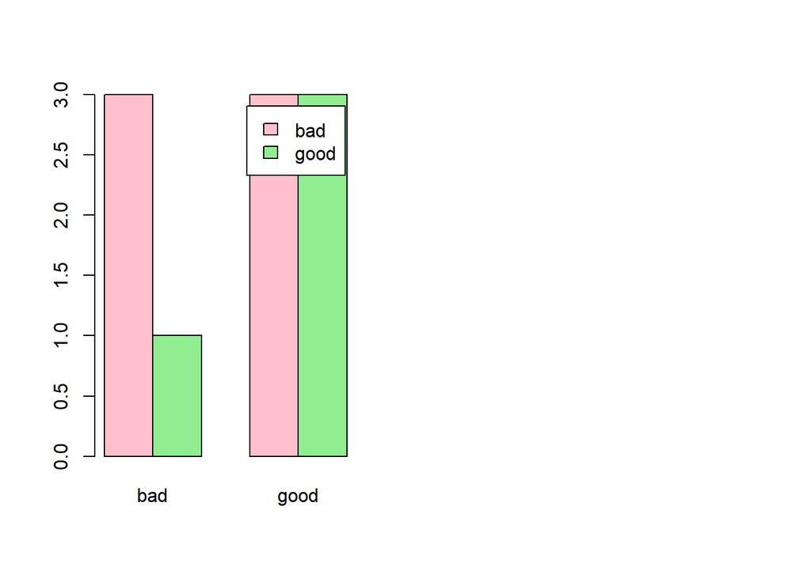

```r
barplot(tab, beside = T,
        legend.text = c("bad", "good"), #Cambiando etiquetas "barras"
        names.arg = c("bad", "good"), #Cambiando etiquetas "eje X"
        col = c("pink", "lightgreen")) #Cambiando colores, "ayudando" a interpretar
```

## 2.2 Variables **cuantitativas/numéricas**

Para mostrar como trabajar con variables cuantitativas se cargará el fichero “Variables.Rdata”, que contiene cuatro variables denominadas como Var1, Var2, Var3 y Var4, siendo todas ellas vectores de la misma longitud.

```
load("Variables.Rdata")
```

> *Recordatorio:* Para poder cargar este fichero bien debe estar en el directorio de trabajo, bien debe especificarse su ubicación/ruta o… (véase el apartado “Importar/exportar datos” de la introducción a R).

### 2.2.1 Histogramas

Con cada una de estas variables se pueden realizar gráficos de manera similar al apartado de estadística descriptiva utilizando la función `hist()`. De esta manera, si lo utilizamos con una única variable nos muestra el histograma de la misma.

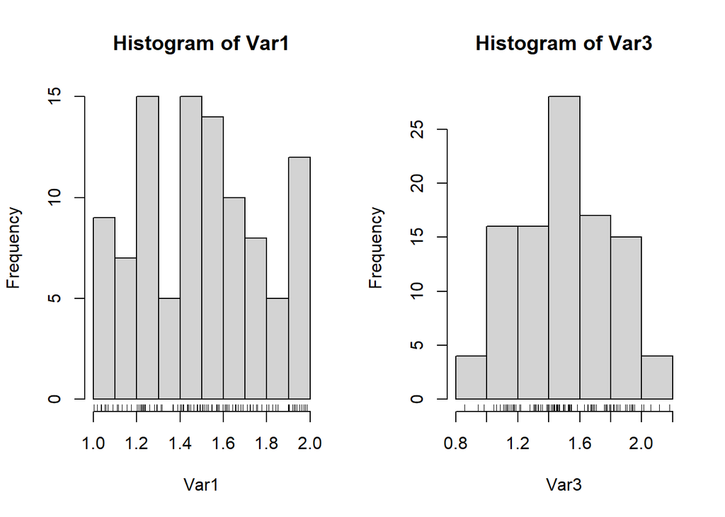

```r
par(mfrow = c(1, 2))
hist(Var1); rug(Var1)
hist(Var3); rug(Var3)
```

Con la función `hist()` sólo se puede “pintar” el histograma de una variable. En el caso de indicar 2 variables, como en

```
hist(Var1, Var3)
```

la función ha interpretado “a su manera” la segunda variable, pero no tiene sentido mostrar los valores de esta forma ¿por qué?… No es la superposición de los histogramas de las dos variables que sería lo deseable.

> En la página web del profesor de la UCLM [Emilio López Cano](http://emilio.lcano.com/r_examples/superponer_histogramas.html) se puede ver un ejemplo de dos histogramas superpuestos en el mismo gráfico (y el código para hacerlo).

### 2.2.2 Boxplots

Si en lugar de usar la función `boxplot()` con una única variable o vector de datos, como hicimos en el apartado de estadística unidimensional, la usamos con varias variables/vectores de datos, obtendremos en un solo gráfico la representación de todos los boxplot unidimensionales correspondientes a cada vector.

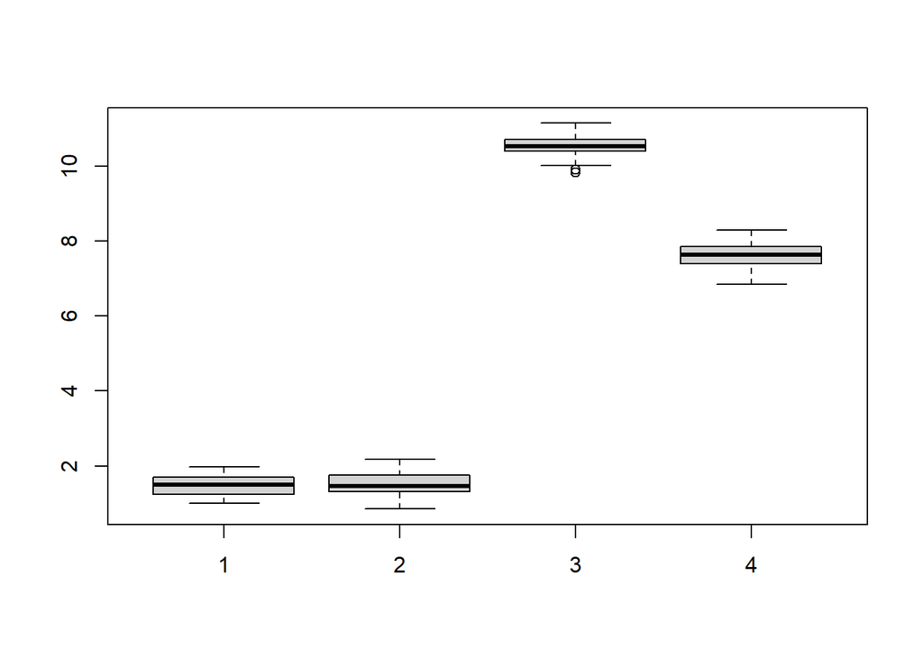

```r
boxplot(Var1, Var3, Var2, Var4)
```

> Obsérvese que `boxplot()` no ha “etiquetado” las variables por su nombre, lo que sería de ayuda. Las ha numerado siguiendo el orden en el que están escritas y por tanto el primer boxplot es de Var1, pero el segundo es de Var3, lo que puede llevar a errores.

### 2.2.3 Diagramas de dispersión (Scatterplots)

Para realizar este tipo de diagramas en R se utiliza la función `plot()`, introduciendo como entrada **dos variables** cuya longitud debe ser la misma (primero la variable $x$, la que juega el papel de variable explicativa o independiente, que se dispondrá en el eje horizontal de la gráfica, y después la variable $y$, la dependiente, respuesta o explicada, que se dispondrá en el eje vertical).

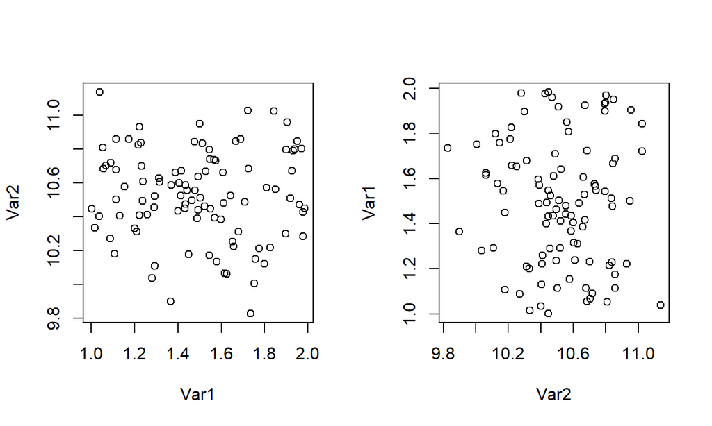

```r
par(mfrow = c(1, 2))
plot(Var1, Var2)
plot(Var2, Var1) #¡Ojo! Distinto al anterior, ahora Var2 está en el eje X
```

> Conviene que los diagramas de dispersión se presenten en **formato cuadrado**, en lugar de rectangular. Para ello se puede ajustar manualmente el tamaño de la ventana de Plots y el gráfico se ajustará automáticamente.  
> No obstante, es mucho mejor utilizar el parámetro para gráficos definido para ello, concretamente a partir de ahora ejecutaremos, siempre previo a los diagramas de dispersión:  
> `par(pty = "s")` (le da ese formato *squared*).  
> Si se quiere volver al “formato” por defecto de R: `par(pty = "m")` (*maximal*).

## 2.3 Data frames

Como ya se comentó en la introducción, R proporciona un tipo de estructura de datos denominada `data.frame` que generaliza a las matrices, permitiéndonos almacenar en cada columna datos de un tipo diferente al de las otras columnas (lo que le diferencia de las matrices). En cada columna, que corresponderá con una variable, los valores deben ser del mismo tipo y la longitud de todas ellas debe ser igual. Esto es muy útil a la hora de almacenar diferentes observaciones relacionadas con una determinada muestra sobre diferentes aspectos/variables, tanto cualitativos como numéricos/cuantitativos.

Creemos varios data frames con la función `data.frame()`:

```r
Multi <- data.frame(Var2, Var3, Var4, Var1) #Se han "descolocado" las variables adrede
head(Multi) #Muestra las primeras observaciones (lineas)
```

```
##       Var2     Var3     Var4     Var1
## 1 10.47448 1.446677 7.878497 1.435940
## 2 10.84440 1.464245 7.389377 1.666536
## 3 10.66044 1.627750 7.484558 1.607355
## 4 10.38925 1.357577 7.647873 1.489433
## 5 10.71740 1.127545 7.941077 1.090547
## 6 10.55967 1.820081 7.191718 1.851039
```

```r
tail(Multi) #Muestra las últimas observaciones (lineas)
```

```
##          Var2     Var3     Var4     Var1
## 95  10.587473 1.417969 7.414449 1.367607
## 96  10.797706 2.058260 7.124470 1.937370
## 97  10.445756 1.530968 7.706224 1.548761
## 98   9.899139 1.402872 7.766898 1.365493
## 99  10.391261 1.355791 7.534971 1.570414
## 100 10.636651 1.424067 7.566425 1.492647
```

```r
( x4 <- data.frame(estatura = c(150, 165, 172, 180),
                   peso = c(56, 62, 80, 90),
                   estcivil = c("s", "s", "c", "d")) )
```

```
##   estatura peso estcivil
## 1      150   56        s
## 2      165   62        s
## 3      172   80        c
## 4      180   90        d
```

> Como se ha comentado anteriormente, todas las columnas de los data.frame deben tener la misma longitud. En el caso de que se introduzca una variable con una longitud menor que alguna otra variable, R dará un error, a no ser que la longitud del vector mayor sea múltiplo de la longitud del vector menor. En ese caso R se encargará de ajustar la longitud de esas columnas/vectores repitiendo los valores de la variable de menor longitud tantas veces como sean necesarias hasta rellenar completamente la columna. En el siguiente código podemos ver como ocurre esto para las variables `baseline` y `testing`, que solo tenían 10 elementos pero se repiten 10 veces sus valores (en el mismo orden) para ajustarse a las 100 observaciones de `Var4` y `Var1`.

```r
Multi2 <- data.frame(baseline, Var4, Var1, testing)
tail(Multi2)
```

```
##     baseline     Var4     Var1 testing
## 95         b 7.414449 1.367607       0
## 96         g 7.124470 1.937370       1
## 97         b 7.706224 1.548761       0
## 98         g 7.766898 1.365493       0
## 99         g 7.534971 1.570414       1
## 100        b 7.566425 1.492647       1
```

**Acceso a variables del data.frame**

Para acceder al contenido de las variables (columnas) se puede realizar de varias maneras.  
Una posibilidad: `nombredataframe$nombrevariable`:

```r
Multi2$baseline
```

```
##   [1] "b" "b" "g" "b" "b" "g" "b" "g" "g" "b" "b" "b" "g" "b" "b" "g" "b" "g"
##  [19] "g" "b" "b" "b" "g" "b" "b" "g" "b" "g" "g" "b" "b" "b" "g" "b" "b" "g"
##  [37] "b" "g" "g" "b" "b" "b" "g" "b" "b" "g" "b" "g" "g" "b" "b" "b" "g" "b"
##  [55] "b" "g" "b" "g" "g" "b" "b" "b" "g" "b" "b" "g" "b" "g" "g" "b" "b" "b"
##  [73] "g" "b" "b" "g" "b" "g" "g" "b" "b" "b" "g" "b" "b" "g" "b" "g" "g" "b"
##  [91] "b" "b" "g" "b" "b" "g" "b" "g" "g" "b"
```

```r
mtcars$cyl #Ya se explicó arriba que mtcars es un data frame que está en R
```

```
##  [1] 6 6 4 6 8 6 8 4 4 6 6 8 8 8 8 8 8 4 4 4 4 8 8 8 8 4 4 4 8 6 8 4
```

O de la misma manera que se accede a una matriz de datos:

```r
Multi2[ ,1] #Columna 1 (=baseline)
```

```
##   [1] "b" "b" "g" "b" "b" "g" "b" "g" "g" "b" "b" "b" "g" "b" "b" "g" "b" "g"
##  [19] "g" "b" "b" "b" "g" "b" "b" "g" "b" "g" "g" "b" "b" "b" "g" "b" "b" "g"
##  [37] "b" "g" "g" "b" "b" "b" "g" "b" "b" "g" "b" "g" "g" "b" "b" "b" "g" "b"
##  [55] "b" "g" "b" "g" "g" "b" "b" "b" "g" "b" "b" "g" "b" "g" "g" "b" "b" "b"
##  [73] "g" "b" "b" "g" "b" "g" "g" "b" "b" "b" "g" "b" "b" "g" "b" "g" "g" "b"
##  [91] "b" "b" "g" "b" "b" "g" "b" "g" "g" "b"
```

```r
Multi2[5:6, 1] #Filas 5 y 6, columna 1
```

```
## [1] "b" "g"
```

Además, es importante tener en cuenta que puede existir confusión a la hora de generar los data.frame si utilizamos valores numéricos en los *argumentos* en lugar de los nombres de las variables:

```
Multi$Var4 == Multi[, 4]
```

Sin embargo con la siguiente sentencia se comprueba que `baseline` sí es la columna 1 de `Multi2`

```
Multi2$baseline == Multi2[ ,1]
```

**Ventajas de trabajar con data frames**

Hay muchas ventajas en la forma de trabajar con data.frame en lugar de otro tipo de estructuras de datos, y es que R está implementado en su mayor parte para trabajar con esta estructura. Por ejemplo, podemos utilizar la función `summary()` para obtener resúmenes de la información de todas las observaciones almacenadas en el data.frame:

```r
summary(Multi)
```

```
##       Var2             Var3             Var4            Var1
##  Min.   : 9.827   Min.   :0.8556   Min.   :6.835   Min.   :1.002
##  1st Qu.:10.388   1st Qu.:1.3120   1st Qu.:7.393   1st Qu.:1.255
##  Median :10.515   Median :1.4561   Median :7.626   Median :1.493
##  Mean   :10.524   Mean   :1.5031   Mean   :7.618   Mean   :1.492
##  3rd Qu.:10.706   3rd Qu.:1.7603   3rd Qu.:7.847   3rd Qu.:1.694
##  Max.   :11.137   Max.   :2.1811   Max.   :8.296   Max.   :1.984
```

```r
summary(Multi2)
```

```
##    baseline              Var4            Var1          testing
##  Length:100         Min.   :6.835   Min.   :1.002   Min.   :0.0
##  Class :character   1st Qu.:7.393   1st Qu.:1.255   1st Qu.:0.0
##  Mode  :character   Median :7.626   Median :1.493   Median :1.0
##                     Mean   :7.618   Mean   :1.492   Mean   :0.6
##                     3rd Qu.:7.847   3rd Qu.:1.694   3rd Qu.:1.0
##                     Max.   :8.296   Max.   :1.984   Max.   :1.0
```

Nótese la diferencia de “resumen” entre variables nominales y numéricas (más bien entre variables cuyos valores son de tipo carácter y variables cuyos valores son números, pues como se vio `testing` es una variable nominal que se ha definido con valores numéricos).

O también podemos dibujar los boxplot directamente:

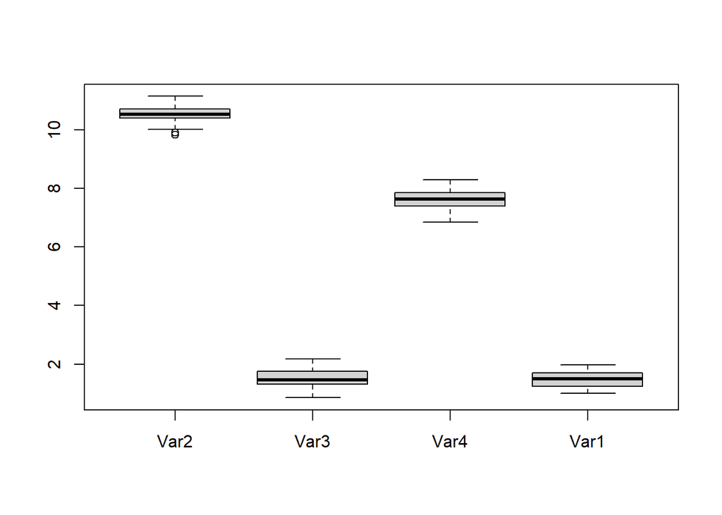

```
## [1] "stats" "n"     "conf"  "out"   "group" "names"
```

```r
boxplot(Multi) #Nótese que ahora las etiquetas son los nombres de las variables... ¡gran ayuda!
names(boxplot(Multi)) #"componentes" del objeto generado con boxplot()
```

```r
boxplot(Multi)$out #Atípicos (de todas las variables del data frame)
```

```
## [1] 9.827259 9.899139
```

Pero cuidado con lo que se le pide:

```r
boxplot(Multi2)
```

```
## Error in x[floor(d)] + x[ceiling(d)]: argumento no-numérico para operador binario
```

Al ser `baseline` una variable categórica cuyos valores son “letras” no se puede “dibujar” su boxplot.  
(NOTA: En versiones anteriores R “interpretaba” dicha variable -transformaba internamente las letras de la variable en números- para poder hacer el gráfico conjunto.)

También podemos dibujar con una sola función todos los diagramas de dispersión posibles entre todas las parejas de variables almacenadas en el data.frame utilizando la función `pairs()`:

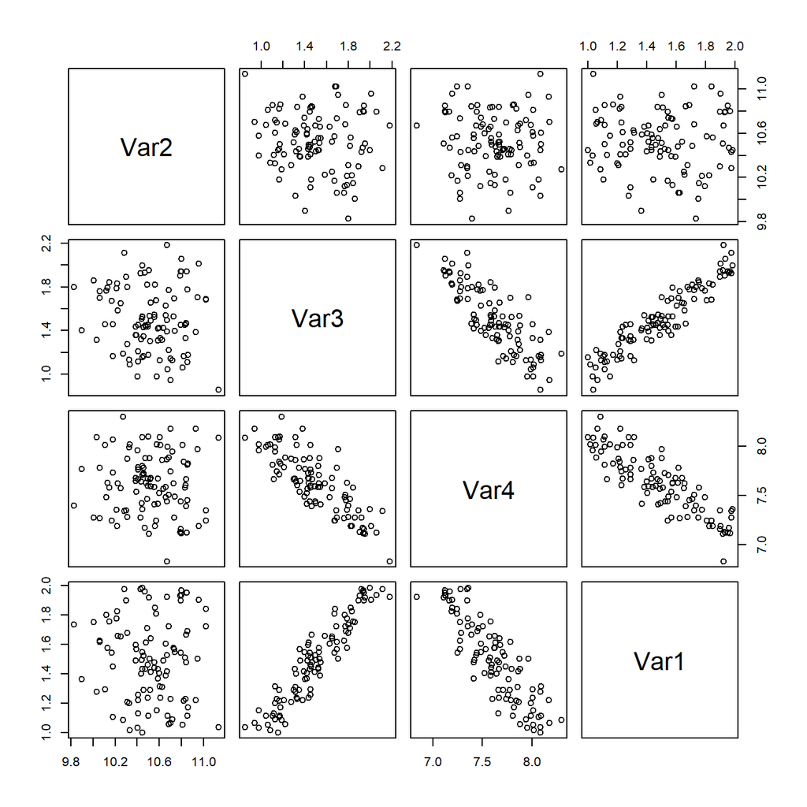

```r
pairs(Multi)
```

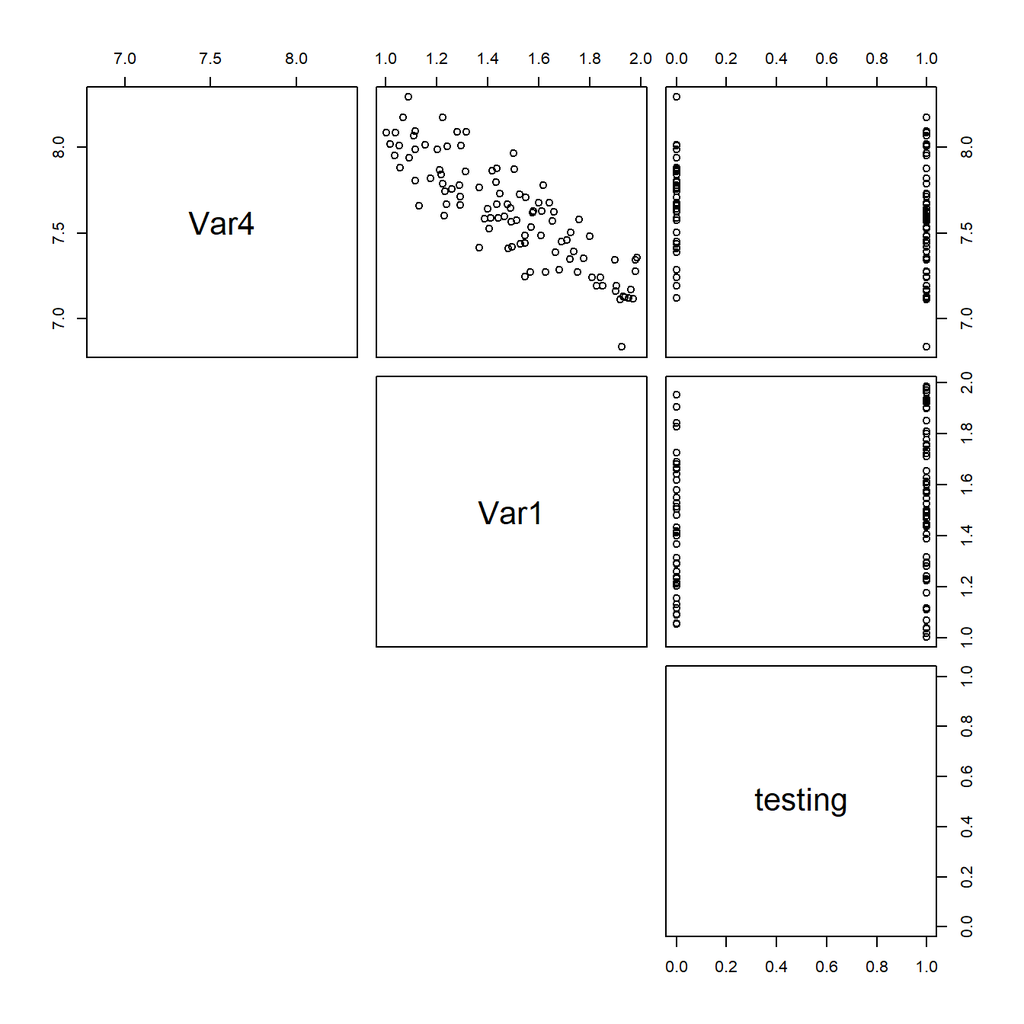

```r
pairs(Multi2[,2:4], lower.panel = NULL)
```

> ¡Ojo! R representa diagramas de dispersión si en las variables encuentra números, como en `testing`, pero sabemos que es una variable ¡categórica! Por ello no tiene sentido pintar su diagrama de dispersión frente a variables numéricas!! (Toma nota!!)

Finalmente, para guardar un data frame:

```
save(Multi, file = "MultiV.Rdata")
save(Multi2, file = "MultiV_2.Rdata")
```

## 2.4 Correlación lineal

En el estudio de la correlación lineal hemos de diferenciar entre la intensidad que tiene y lo significativa (estadísticamente hablando) que es.

La **intensidad** de la correlación lineal nos la puede proporcionar el coeficiente de correlación lineal de Pearson, entre otros. En R se obtiene con la función `cor()`:

```r
cor(Var1, Var3)
```

```
## [1] 0.9386554
```

> - Si las variables tienen la misma longitud, pero hay algún valor perdido en una de ellas se puede usar el *argumento* `use = "pairwise.complete.obs"`.
> - Por defecto `cor` calcula el coeficiente de correlación lineal de Pearson. Mediante el *argumento* `method` se pueden obtener los coeficientes de correlación de *Kendall* y de *Spearman*.

Si se aplica a un data.frame, nos proporcionará el coeficiente de correlación lineal de cada par de vectores:

```r
cor(Multi)
```

```
##             Var2       Var3        Var4       Var1
## Var2  1.00000000 -0.1131052 -0.05237036 -0.0454823
## Var3 -0.11310521  1.0000000 -0.83025404  0.9386554
## Var4 -0.05237036 -0.8302540  1.00000000 -0.8634720
## Var1 -0.04548230  0.9386554 -0.86347203  1.0000000
```

> Esta **matriz de correlaciones** tiene en su diagonal unos, puesto que cada variable está perfectamente correlacionada consigo misma.

Además de obtener el coeficiente de correlación lineal es importante realizar un análisis visual de los diagramas de dispersión, utilizando la función `pairs()` como mostrábamos en la sección anterior.

En cualquier caso, el nivel de intensidad no tiene sentido si la correlación no es estadísticamente **significativa**. Pero este concepto pertenece a la parte de Inferencia Estadística que se verá más adelante. Por lo que aquí se explicará muy brevemente. Para averiguar si la correlación es o no significativa (significativamente distinta de 0), se debe hacer el correspondiente *test* o *contraste de hipótesis*. Por ejemplo, con la función `cor.test()`:

```
cor.test(Var1, Var3)
```

> Si el *p-valor* obtenido en el test es menor que el nivel de significación establecido (en el 5% habitualmente) podremos considerar que la correlación es *significativa* y entonces tendrá sentido valorar su *intensidad*: débil, moderada, fuerte…

## 2.5 Regresión lineal simple

La regresión lineal simple es un modelo matemático que se utiliza para aproximar la relación de dependencia entre dos variables numéricas/cuantitativas, una dependiente (Y) y otra independiente (X), mediante una recta de ecuación $y = a + bx$.

> **Hipótesis de partida:** Hay que hacer constar aquí que la utilización de este modelo implica que se cumplan unos requisitos, a saber: normalidad, homocedasticidad e independencia de los residuos obtenidos. Dichos requisitos se pueden comprobar una vez obtenido el modelo, pero para ello se necesitan técnicas de inferencia que veremos más adelante en el temario. Por lo que no estamos ahora en disposición de dar aquí detalles.

Para estudiar este tipo de modelo, primero vamos a cargar los datos del fichero `emisiones.Rdata`. En este fichero se almacenan los datos de PIB, renta per cápita y las emisiones de CO2 realizadas por diferentes países.

```
load("emisiones.Rdata")
```

Podemos obtener información de este tipo de datos utilizando algunas de las funciones que hemos visto previamente:

```r
head(emisiones)
```

```
##                   PIB perCapita  CO2
## UnitedStates  8083000     29647 6750
## Japan         3080000     24409 1320
## Germany       1740000     21197 1740
## France        1320000     22381  550
## UnitedKingdom 1242000     21010  675
## Italy         1240000     21856  540
```

```r
summary(emisiones)
```

```
##       PIB            perCapita          CO2
##  Min.   :  59900   Min.   : 2507   Min.   :  54.0
##  1st Qu.: 123100   1st Qu.:13393   1st Qu.:  77.0
##  Median : 206250   Median :20993   Median : 200.0
##  Mean   : 830427   Mean   :17724   Mean   : 669.4
##  3rd Qu.: 683500   3rd Qu.:22250   3rd Qu.: 547.5
##  Max.   :8083000   Max.   :29647   Max.   :6750.0
```

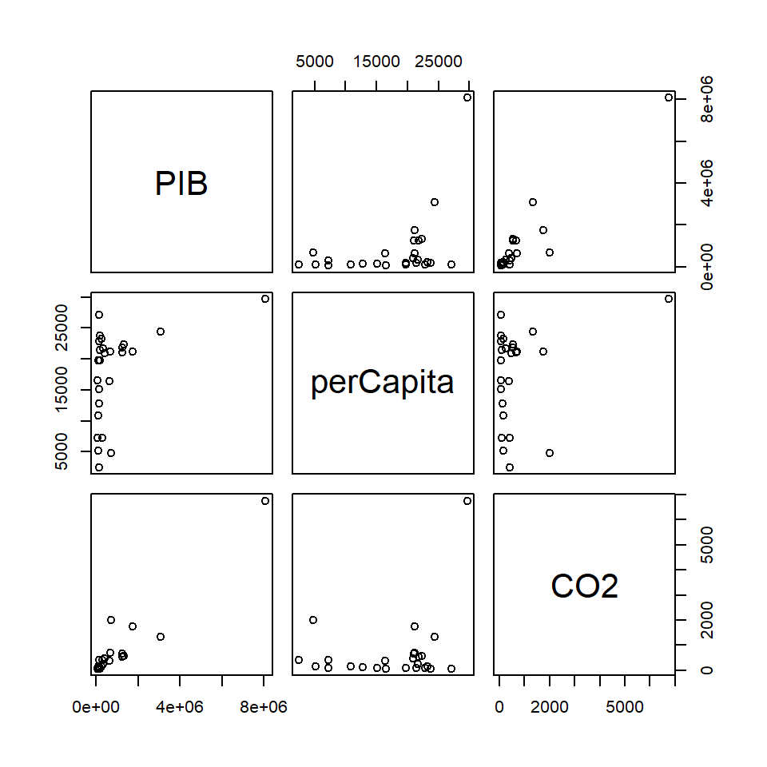

```r
pairs(emisiones)
```

```r
cor(emisiones)
```

```
##                 PIB perCapita       CO2
## PIB       1.0000000 0.4325303 0.9501753
## perCapita 0.4325303 1.0000000 0.2757962
## CO2       0.9501753 0.2757962 1.0000000
```

Como se puede ver en los resultados, la mayor *correlación* se observa entre las variables PIB y CO2, por lo que vamos a centrarnos en este caso de estudio.

Dado que la correlación entre PIB y CO2 es la misma que entre CO2 y PIB (basta ver la fórmula de su cálculo) es esencial para el análisis de regresión que se identifiquen de antemano las variables que juegan el papel de la X y de la Y. La intención es explicar como los cambios en la variable X explican los cambios en la variable Y, de forma lineal. En este ejemplo lo lógico es considerar PIB como variable independiente, X, y CO2 como variable dependiente, Y. Es decir, queremos explicar cómo la variación en el PIB influye en las emisiones de CO2. Dicha relación dependiente/independiente tiene más sentido que la contraria, ver cómo la variación de emisiones de CO2 hace variar el PIB.

Tomamos estos dos vectores de datos, los almacenamos en dos variables auxiliares y comprobamos si la correlación es *significativa* con `cor.test`:

```r
CO2v <- emisiones$CO2     #Se "crean" estos nuevos objetos para "comodidad" en el manejo de los nombres
PIBv <- emisiones$PIB
cor.test(PIBv, CO2v)      #Correlación significativa si p-valor < 0.05
```

```
##
##  Pearson's product-moment correlation
##
## data:  PIBv and CO2v
## t = 14.933, df = 24, p-value = 1.197e-13
## alternative hypothesis: true correlation is not equal to 0
## 95 percent confidence interval:
##  0.8906170 0.9776873
## sample estimates:
##       cor
## 0.9501753
```

Una vez comprobado que la correlación es significativa (p-valor = `1.197e-13`) y que tiene, en este caso, una intensidad fuerte (cor = `0.9501753`, aunque, a pesar del alto valor de la correlación, en el gráfico no se observan los puntos muy alineados a una recta), procedemos a crear el modelo de regresión lineal que nos permitirá realizar predicciones.

**Definición del modelo**

Para crear un modelo de regresión lineal en R se utiliza el *operador* `~`, que nos relacionará las variables independiente y dependiente de la forma `Y ~ X`. En nuestro caso, la relación es `CO2v ~ PIBv`. Obtendremos la recta de regresión de las emisiones de CO2 (variable dependiente) en función del PIB del país (variable independiente) usando la función `lm()`.

```r
model <- CO2v ~ PIBv
reg <- lm(model)
names(reg)
```

```
##  [1] "coefficients"  "residuals"     "effects"       "rank"
##  [5] "fitted.values" "assign"        "qr"            "df.residual"
##  [9] "xlevels"       "call"          "terms"         "model"
```

```r
summary(reg)       #Resumen del modelo de regresión ajustado con los datos
```

```
##
## Call:
## lm(formula = model)
##
## Residuals:
##      Min       1Q   Median       3Q      Max
## -1107.35   -81.47   -32.69   126.33  1438.79
##
## Coefficients:
##              Estimate Std. Error t value Pr(>|t|)
## (Intercept) 2.043e+01  9.441e+01   0.216     0.83
## PIBv        7.815e-04  5.233e-05  14.933  1.2e-13 ***
## ---
## Signif. codes:  0 '***' 0.001 '**' 0.01 '*' 0.05 '.' 0.1 ' ' 1
##
## Residual standard error: 427.4 on 24 degrees of freedom
## Multiple R-squared:  0.9028, Adjusted R-squared:  0.8988
## F-statistic:   223 on 1 and 24 DF,  p-value: 1.197e-13
```

De esta forma obtendremos la recta de regresión $y = a+bx$. Los coeficientes $a$ (ordenada en el origen, constante, muchas veces traducido directamente como intercepto) y $b$ (pendiente de la recta) se muestran en la columna `Estimate` (¡Ojo! con la notación científica: 2.043e+01 = 20.43).

De nuevo, haciendo uso aquí de las herramientas de inferencia, *contrastes de hipótesis*, podemos observar en los resultados, los p-valores de los coeficientes $a$ y $b$ de la recta (columna con cabecera `Pr(>|t|)`), que nos permite decidir si son significativos (significativamente distintos de 0) y por tanto deben incluirse en la ecuación de la recta. En el ejemplo la constante tiene un p-valor > 0.05, por lo que no es significativa (estadísticamente no es distinta de 0: no se pone en la ecuación). Mientras que la pendiente tiene un p-valor < 0.05 (de hecho coincide con el del `cor.test`), por lo que dicho coeficiente es significativo: ha de estar en la ecuación de la recta de regresión.

> Todo esto se sustenta en unas *hipótesis* del modelo de regresión que deberían comprobarse. Veremos cuáles son y cómo comprobarlas en la parte de inferencia. De hecho, si no se cumplen las hipótesis no se puede obtener conclusiones del modelo de regresión.

**Gráficamente**

Para representar la recta de regresión en el diagrama de dispersión se puede utilizar la función `abline`:

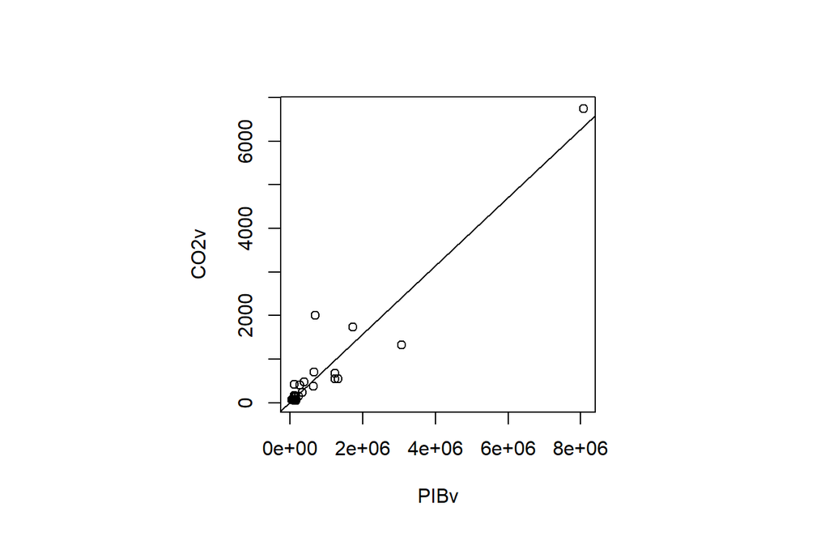

```r
par(pty = "s")
plot(model)
abline(reg) #Toma los valores a y b estimados en la regresión (aunque no sean significativos!)
```

> **Nota:**

> ¿Qué ocurriría si no se tuviese el país con valores atípicos (PIB en torno a 8e+06 y CO2 en torno a 7000)?  
> Ese país se etiqueta en Estadística como “observación influyente”. Y es el que hace que se tenga una altísima correlación sin que los puntos estén muy alineados en torno a una recta.

> En este caso, se trata de un outlier que proviene de un dato válido (dato real de un país concreto), por lo que no se puede eliminar, pero es interesante hacer un análisis paralelo de todo el conjunto de datos salvo ese, y compararlos para calibrar la influencia de ese dato en el conjunto:

> ```r
> max(PIBv); which.max(PIBv) #Averiguamos de qué observación (país) se trata
> ```

> ```
> ## [1] 8083000
> ```

> ```
> ## [1] 1
> ```

> ```r
> CO2v1 <- CO2v[-1] #Creamos nuevas variables para "quitar" dicha observación
> PIBv1 <- PIBv[-1]
> cor(CO2v1, PIBv1) #Calculamos la correlación sin dicha observación
> ```

> ```
> ## [1] 0.7000287
> ```

> Primer hecho relevante: $r = 0.95 \rightarrow r = 0.70$

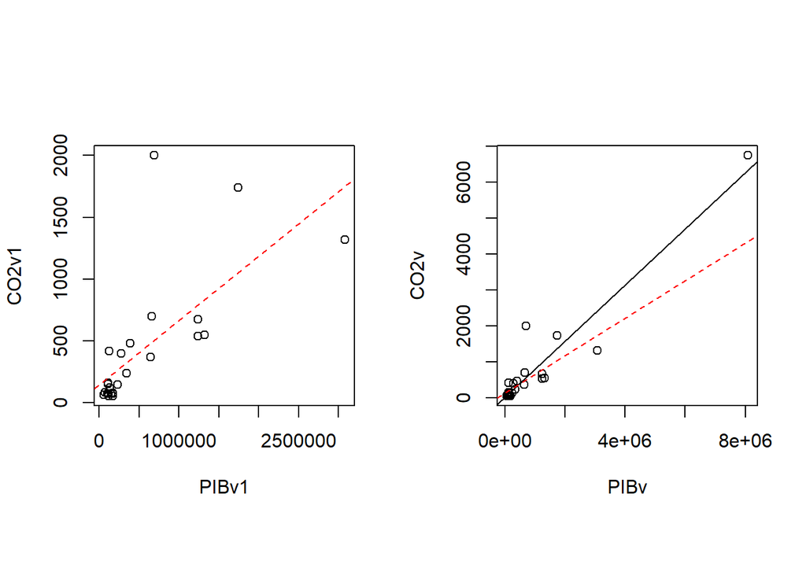

> ```r
> model1 <- CO2v1 ~ PIBv1
> reg1 <- lm(model1)
> par(mfrow = c(1,2), pty = "s")
> plot(model1)
> abline(reg1, lty = 2, col = "red")
> plot(model)
> abline(reg)
> abline(reg1, lty = 2, col = "red")
> ```

> Segundo hecho relevante: cambia (obviamente) la recta (la roja y discontinua es la obtenida al quitar dicha *observación influyente*).  
> Lo de obviamente es para enfatizar que $b$, la pendiente de la recta, depende (véase la formula teórica) de la covarianza entre las dos variables, como también depende el coeficiente de correlación. Así que, como hemos visto que $r$ sufre un considerable cambio al quitar dicha observación, la recta sufre ese cambio.

**Predicciones**

Finalmente, para hacer predicciones R proporciona la función `predict()`. Se utiliza indicando en un vector, con `c()`, los valores de la variable $x$ (independiente) para los que queremos estimar sus correspondientes valores de la variable $y$ (dependiente).

```r
pred <- predict(reg, data.frame(PIBv <- c(2e6, 4e6, 6e6))); pred
```

```
##        1        2        3
## 1583.367 3146.300 4709.233
```

> ¡Ojo! Las predicciones cambian mucho sin la *observación influyente* comentada.

> ```r
>  ( pred1 <- predict(reg1, data.frame(PIBv1 <- c(2e6, 4e6, 6e6))) )
> ```

> ```
> ##        1        2        3
> ## 1187.724 2231.193 3274.663
> ```

> ```r
>  pred1 - pred
> ```

> ```
> ##          1          2          3
> ##  -395.6431  -915.1066 -1434.5702
> ```

> Gráficamente

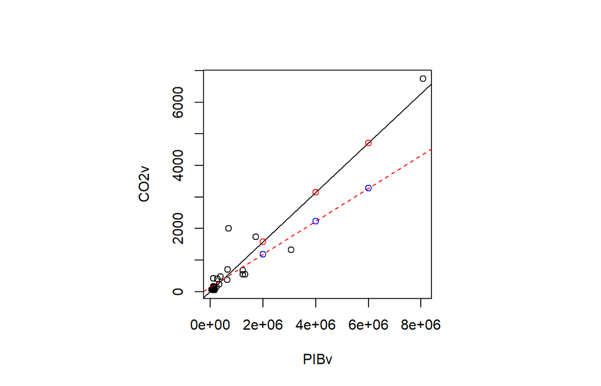

> Así que ¡cuidado con las *extrapolaciones*! (porque quitando el último dato -atípico- dos de las predicciones estarían más allá del rango de valores muestrales del PIB, por lo que quizá no sea fiable el modelo para esos valores de PIB)  
> Y por lo mismo ¡También cuidado con las *interpolaciones*, predicciones de valores situados entre la masa de datos y los outliers, cuando no se quitan los outliers!